# NEET and mental health meta-analyses

Sofia Danna

14 November 2019

# Mise en place

Will be using this tutorial for analyses: https://bookdown.org/MathiasHarrer/Doing_Meta_Analysis_in_R/

These are the updated data that Gen and I decided on 18 October 2019. There should no longer be any repeated samples pooled together. All variables should be accurately re-derived. It was the dataset Sofia saved after running all of these analyses in R.

```r
neet2 <- read.csv("C:/Users/dansof/Dropbox/PEPP new/NEET meta-analysis/metaanalysis/neet2.csv")
```

checking out the variables in the updated NEET dataframe

```r
neet2
```

| X | Study | Country | study_no | Mental.health.measures | Temporality.of.measures | Results | Repeated_sample | MH_measure | MH.measure.included | Gender | OR | LowerCI | UpperCI | OR_ln | lower_ln | upper_ln | SE | LowerCI_sens | UpperCI_sens | Distress | Mood | Anxiety | Behavioral | Alcohol | Cannabis | Drug | Suicidal | Any |
| --- | --- | --- | --- | --- | --- | --- | --- | --- | --- | --- | --- | --- | --- | --- | --- | --- | --- | --- | --- | --- | --- | --- | --- | --- | --- | --- | --- | --- |
| 28 | Benjet, 2012 | Mexico | benjet 2012 5 | Any disorder | MHNEET | OR 1.7, 95% CI 1.3, 2.3 | NA | any | NA | all | 1.700 | 1.300 | 2.300 | 0.530628251 | 0.262364264 | 0.832909123 | 0.14554716 | NA | NA | 0 | 0 | 0 | 0 | 0 | 0 | 0 | 0 | 1 |
| 111 | Power, 2015 | Ireland | power 2015 7 | Any lifetime disorder | MHNEET | OR 2.9, 95% CI 1.1, 7.2 | NA | any | NA | all | 2.900 | 1.100 | 7.200 | 1.064710737 | 0.095310180 | 1.974081026 | 0.47927828 | NA | NA | 0 | 0 | 0 | 0 | 0 | 0 | 0 | 0 | 1 |
| 115 | Power, 2015 | Ireland | power 2015 10 | Any diagnosis in adolescence | MH-->NEET | OR 3.1, 95% CI 1.4, 7.0 | NA | any | NA | all | 3.100 | 1.400 | 7.000 | 1.131402111 | 0.336472237 | 1.945910149 | 0.41057090 | NA | NA | 0 | 0 | 0 | 0 | 0 | 0 | 0 | 0 | 1 |
| 117 | Rodwell, 2018 | Australia | rodwell 2018 1 | Common mental disorders | MH-->NEET | OR 1.60, 95% CI 1.07, 2.40 | NA | any | NA | all | 1.600 | 1.070 | 2.400 | 0.470003629 | 0.067658648 | 0.875468737 | 0.20607400 | NA | NA | 0 | 0 | 0 | 0 | 0 | 0 | 0 | 0 | 1 |
| 31 | Benjet, 2012 | Mexico | benjet 2012 8 | Suicidal attempt | MHNEET | OR 3.6, 95% CI 2.0, 6.4 | NA | suicide | NA | all | 3.600 | 2.000 | 6.400 | 1.280933845 | 0.693147181 | 1.856297990 | 0.29672214 | NA | NA | 0 | 0 | 0 | 0 | 0 | 0 | 0 | 1 | 0 |
| 42 | Gariepy, 2018 | Canada | gariepy 2018 7 | Suicidal ideation | MHNEET | OR 1.8, 95% CI 1.0, 3.1 | NA | suicide | NA | all | 1.800 | 1.000 | 3.100 | 0.587786665 | 0.000000000 | 1.131402111 | 0.28862299 | NA | NA | 0 | 0 | 0 | 0 | 0 | 0 | 0 | 1 | 0 |
| 53 | Goldman-Mellor, 2016 | UK | goldman 2016 9 | Suicidal behaviours | MH-->NEET | OR 3.30, 95% CI 2.07, 5.27 | NA | suicide | NA | all | 3.300 | 2.070 | 5.270 | 1.193922468 | 0.727548607 | 1.662030363 | 0.23838820 | NA | NA | 0 | 0 | 0 | 0 | 0 | 0 | 0 | 1 | 0 |
| 62 | Gutierrez-Garcia, 2017 | Mexico | gutierrez 2017 8 | Suicidal attempt | NEET-->MH | OR 2.40, 95% CI 1.30, 4.31 | 1 | suicide | NA | all | 2.400 | 1.300 | 4.310 | 0.875468737 | 0.262364264 | 1.460937904 | 0.30575858 | NA | NA | 0 | 0 | 0 | 0 | 0 | 0 | 0 | 1 | 0 |
| 72 | Gutierrez-Garcia, 2019 | Mexico | gutierrez 2019 9 | Suicidal attempt | MHNEET | OR 2.75, 95% CI 1.79, 4.25 | 1 | suicide | NA | all | 2.750 | 1.790 | 4.250 | 1.011600912 | 0.582215620 | 1.446918983 | 0.22058759 | NA | NA | 0 | 0 | 0 | 0 | 0 | 0 | 0 | 1 | 0 |
| 110 | Power, 2015 | Ireland | power 2015 6 | Suicidal attempts (lifetime) | MHNEET | OR 3.1, 95% CI 1.0, 9.3 | NA | suicide | NA | all | 3.100 | 1.000 | 9.300 | 1.131402111 | 0.000000000 | 2.230014400 | 0.56888123 | NA | NA | 0 | 0 | 0 | 0 | 0 | 0 | 0 | 1 | 0 |

[output cut: 93 more lines]

```r
str(neet2)
```

```
## 'data.frame':    103 obs. of  29 variables:
##  $ X                      : int  28 111 115 117 31 42 53 62 72 110 ...
##  $ Study                  : Factor w/ 15 levels "Baggio, 2015",..: 4 14 14 15 4 6 7 8 9 14 ...
##  $ Country                : Factor w/ 8 levels "Australia","Canada",..: 5 4 4 1 5 2 8 5 5 4 ...
##  $ study_no               : Factor w/ 103 levels "baggio 2015 1",..: 24 97 91 100 27 37 46 54 63 96 ...
##  $ Mental.health.measures : Factor w/ 45 levels "Alcohol dependence",..: 10 11 8 18 40 43 42 40 40 41 ...
##  $ Temporality.of.measures: Factor w/ 3 levels "MH-->NEET","MH<-->NEET",..: 2 2 1 1 2 2 1 3 2 2 ...
##  $ Results                : Factor w/ 91 levels "Age<18: OR 0.95, 95% CI 0.72, 1.26",..: 60 79 81 56 84 64 83 74 78 80 ...
##  $ Repeated_sample        : int  NA NA NA NA NA NA NA 1 1 NA ...
##  $ MH_measure             : Factor w/ 9 levels "alcohol","anxiety",..: 3 3 3 3 9 9 9 9 9 9 ...
##  $ MH.measure.included    : logi  NA NA NA NA NA NA ...
##  $ Gender                 : Factor w/ 4 levels "age","all","boy",..: 2 2 2 2 2 2 2 2 2 2 ...
##  $ OR                     : num  1.7 2.9 3.1 1.6 3.6 1.8 3.3 2.4 2.75 3.1 ...
##  $ LowerCI                : num  1.3 1.1 1.4 1.07 2 1 2.07 1.3 1.79 1 ...
##  $ UpperCI                : num  2.3 7.2 7 2.4 6.4 3.1 5.27 4.31 4.25 9.3 ...
##  $ OR_ln                  : num  0.531 1.065 1.131 0.47 1.281 ...
##  $ lower_ln               : num  0.2624 0.0953 0.3365 0.0677 0.6931 ...
##  $ upper_ln               : num  0.833 1.974 1.946 0.875 1.856 ...
##  $ SE                     : num  0.146 0.479 0.411 0.206 0.297 ...
##  $ LowerCI_sens           : int  NA NA NA NA NA NA NA NA NA NA ...
##  $ UpperCI_sens           : num  NA NA NA NA NA NA NA NA NA NA ...
##  $ Distress               : int  0 0 0 0 0 0 0 0 0 0 ...
##  $ Mood                   : int  0 0 0 0 0 0 0 0 0 0 ...
##  $ Anxiety                : int  0 0 0 0 0 0 0 0 0 0 ...
##  $ Behavioral             : int  0 0 0 0 0 0 0 0 0 0 ...
##  $ Alcohol                : int  0 0 0 0 0 0 0 0 0 0 ...
##  $ Cannabis               : int  0 0 0 0 0 0 0 0 0 0 ...
##  $ Drug                   : int  0 0 0 0 0 0 0 0 0 0 ...
##  $ Suicidal               : int  0 0 0 0 1 1 1 1 1 1 ...
##  $ Any                    : int  1 1 1 1 0 0 0 0 0 0 ...
```

installing and loading meta package

```r
install.packages("meta", repos = "http://cran.us.r-project.org")
library(meta)
library(metafor)
```

| Parameter | Function |
| --- | --- |
| TE | This tells R to use the TE column to retrieve the effect sizes for each study |
| seTE | This tells R to use the seTE column to retrieve the standard error for each study |
| data= | After =, paste the name of your dataset here |
| studlab=paste() | This tells the function were the labels for each study are stored. If you named the spreadsheet columns as advised, this should be studlab=paste(Author) |
| comb.fixed= | Whether to use a fixed-effects-model |
| comb.random= | Whether to use a random-effects-model. This has to be set to TRUE |
| method.tau= | Which estimator to use for the between-study variance |
| hakn= | Whether to use the Knapp-Hartung method |
| prediction= | Whether to print a prediction interval for the effect of future studies based on present evidence |
| sm= | The summary measure we want to calculate. We can either calculate the mean difference (MD) or Hedges’ g (SMD) |

using the instructions from the tutorial by Mathias Harrer (url above),

| instead of | we will use |
| --- | --- |
| “Author” | “Study” |
| “TE” | “OR_ln” |
| “seTE” | “SE” |

# Analyses: Mental health measure

## DISTRESS

distress = 1, gender = all, repeated sample = 0

```r
MHdis.Gall.rep0 <- neet2[which(neet2$Distress==1 & neet2$Gender=="all" & is.na(neet2$Repeated_sample)),]

head(MHdis.Gall.rep0)
```

|  | X | Study | Country | study_no | Mental.health.measures | Temporality.of.measures | Results | Repeated_sample | MH_measure | MH.measure.included | Gender | OR | LowerCI | UpperCI | OR_ln | lower_ln | upper_ln | SE | LowerCI_sens | UpperCI_sens | Distress | Mood | Anxiety | Behavioral | Alcohol | Cannabis | Drug | Suicidal | Any |
| --- | --- | --- | --- | --- | --- | --- | --- | --- | --- | --- | --- | --- | --- | --- | --- | --- | --- | --- | --- | --- | --- | --- | --- | --- | --- | --- | --- | --- | --- |
| 75 | 2 | Baggio, 2015 | Switzerland | baggio 2015 1 | General mental health | MH-->NEET | OR 0.90, P<0.001 | NA | distress | NA | all | 0.900 | 0.850 | 0.960 | -0.10536052 | -0.16251893 | -0.040821995 | 0.03104514 | NA | NA | 1 | 0 | 0 | 0 | 0 | 0 | 0 | 0 | 0 |
| 76 | 7 | Bania, 2019 | Norway | bania 2019 1 | Emotional problems | MH-->NEET | calculated | NA | distress | NA | all | 0.971 | 0.918 | 1.023 | -0.02942881 | -0.08555789 | 0.022739487 | 0.02762688 | NA | NA | 1 | 0 | 0 | 0 | 0 | 0 | 0 | 0 | 0 |
| 79 | 14 | Basta, 2019 | Greece | basta 2019 1 | Psychological distress | MHNEET | All: OR 0.98, 95% CI 0.96, 1.01 | NA | distress | NA | all | 0.980 | 0.960 | 1.010 | -0.02020271 | -0.04082199 | 0.009950331 | 0.01295212 | NA | NA | 1 | 0 | 0 | 0 | 0 | 0 | 0 | 0 | 0 |
| 82 | 32 | Bynner, 2002 | UK | bynner 2002 1 | Psychological distress | NEET-->MH | calculated | NA | distress | NA | all | 1.783 | 0.762 | 2.805 | 0.57829734 | -0.27180872 | 1.031403539 | 0.33245211 | NA | NA | 1 | 0 | 0 | 0 | 0 | 0 | 0 | 0 | 0 |
| 85 | 74 | Hale, 2018 | UK | hale 2018 1 | Psychological distress | MH-->NEET | calculated | NA | distress | NA | all | 1.573 | 1.221 | 1.925 | 0.45298462 | 0.19967019 | 0.654925968 | 0.11613668 | NA | NA | 1 | 0 | 0 | 0 | 0 | 0 | 0 | 0 | 0 |
| 88 | 78 | Henderson, 2017 | Canada | henderson 2017 1 | Internalizing disorders | MHNEET | Total: OR 1.15, 95% CI 0.95, 1.38 | NA | distress | NA | all | 1.150 | 0.950 | 1.380 | 0.13976194 | -0.05129329 | 0.322083499 | 0.09524918 | NA | NA | 1 | 0 | 0 | 0 | 0 | 0 | 0 | 0 | 0 |

```r
meta.MHdis.Gall.rep0 <- metagen(OR_ln,
                     SE,
                     data=MHdis.Gall.rep0,
                     studlab=paste(Study),
                     comb.fixed = FALSE,
                     comb.random = TRUE,
                     method.tau = "DL",
                     hakn = FALSE,
                     prediction=FALSE,
                     sm="OR")
meta.MHdis.Gall.rep0
```

```
##                     OR           95%-CI %W(random)
## Baggio, 2015    0.9000 [0.8469; 0.9565]       24.7
## Bania, 2019     0.9710 [0.9198; 1.0250]       25.4
## Basta, 2019     0.9800 [0.9554; 1.0052]       27.7
## Bynner, 2002    1.7830 [0.9293; 3.4209]        1.5
## Hale, 2018      1.5730 [1.2528; 1.9751]        9.0
## Henderson, 2017 1.1500 [0.9542; 1.3860]       11.6
##
## Number of studies combined: k = 6
##
##                          OR           95%-CI    z p-value
## Random effects model 1.0274 [0.9457; 1.1162] 0.64  0.5226
##
## Quantifying heterogeneity:
## tau^2 = 0.0063; H = 2.45 [1.69; 3.55]; I^2 = 83.4% [65.2%; 92.1%]
##
## Test of heterogeneity:
##      Q d.f.  p-value
##  30.09    5 < 0.0001
##
## Details on meta-analytical method:
## - Inverse variance method
## - DerSimonian-Laird estimator for tau^2
```

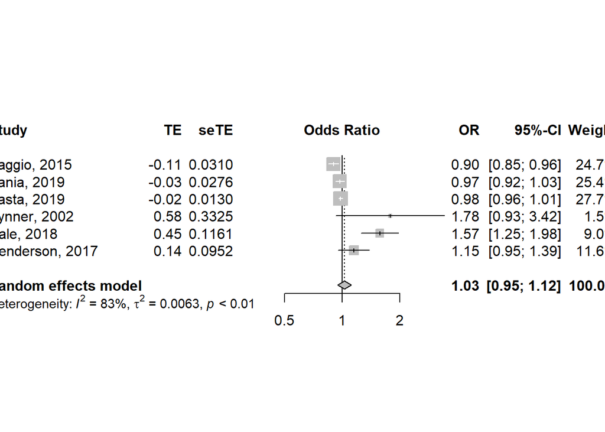

```r
forest(meta.MHdis.Gall.rep0)
```

### DISTRESS - directionality

```r
meta.MHdis.Gall.rep0.dir<-update.meta(meta.MHdis.Gall.rep0,
                                 byvar=Temporality.of.measures,
                                 comb.random = TRUE,
                                 comb.fixed = FALSE)
meta.MHdis.Gall.rep0.dir
```

```
##                     OR           95%-CI %W(random) Temporality.of.measures
## Baggio, 2015    0.9000 [0.8469; 0.9565]       24.7                       1
## Bania, 2019     0.9710 [0.9198; 1.0250]       25.4                       1
## Basta, 2019     0.9800 [0.9554; 1.0052]       27.7                       2
## Bynner, 2002    1.7830 [0.9293; 3.4209]        1.5                       3
## Hale, 2018      1.5730 [1.2528; 1.9751]        9.0                       1
## Henderson, 2017 1.1500 [0.9542; 1.3860]       11.6                       2
##
## Number of studies combined: k = 6
##
##                          OR           95%-CI    z p-value
## Random effects model 1.0274 [0.9457; 1.1162] 0.64  0.5226
##
## Quantifying heterogeneity:
## tau^2 = 0.0063; H = 2.45 [1.69; 3.55]; I^2 = 83.4% [65.2%; 92.1%]
##
## Quantifying residual heterogeneity:
## H = 2.90 [1.89; 4.45]; I^2 = 88.1% [72.0%; 95.0%]
##
## Test of heterogeneity:
##      Q d.f.  p-value
##  30.09    5 < 0.0001
##
## Results for subgroups (random effects model):
##                                        k     OR           95%-CI     Q  tau^2
## Temporality.of.measures = MH-->NEET    3 1.0501 [0.8953; 1.2316] 22.47 0.0162
## Temporality.of.measures = MH<-->NEET   2 1.0325 [0.8914; 1.1959]  2.77 0.0082
## Temporality.of.measures = NEET-->MH    1 1.7830 [0.9293; 3.4209]  0.00     --
##                                        I^2
## Temporality.of.measures = MH-->NEET  91.1%
## Temporality.of.measures = MH<-->NEET 63.9%
## Temporality.of.measures = NEET-->MH     --
##
## Test for subgroup differences (random effects model):
##                     Q d.f. p-value
## Between groups   2.58    2  0.2756
##
## Details on meta-analytical method:
## - Inverse variance method
## - DerSimonian-Laird estimator for tau^2
```

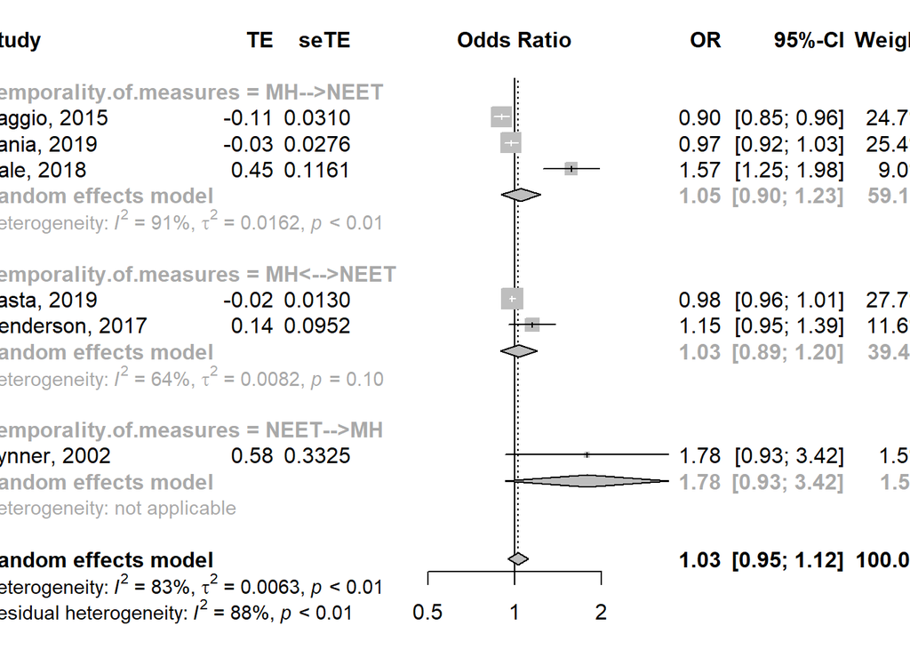

```r
forest(meta.MHdis.Gall.rep0.dir)
```

### DISTRESS - geography

```r
meta.MHdis.Gall.rep0.geo<-update.meta(meta.MHdis.Gall.rep0,
                                      byvar=Country,
                                      comb.random = TRUE,
                                      comb.fixed = FALSE)
meta.MHdis.Gall.rep0.geo
```

```
##                     OR           95%-CI %W(random) Country
## Baggio, 2015    0.9000 [0.8469; 0.9565]       24.7       7
## Bania, 2019     0.9710 [0.9198; 1.0250]       25.4       6
## Basta, 2019     0.9800 [0.9554; 1.0052]       27.7       3
## Bynner, 2002    1.7830 [0.9293; 3.4209]        1.5       8
## Hale, 2018      1.5730 [1.2528; 1.9751]        9.0       8
## Henderson, 2017 1.1500 [0.9542; 1.3860]       11.6       2
##
## Number of studies combined: k = 6
##
##                          OR           95%-CI    z p-value
## Random effects model 1.0274 [0.9457; 1.1162] 0.64  0.5226
##
## Quantifying heterogeneity:
## tau^2 = 0.0063; H = 2.45 [1.69; 3.55]; I^2 = 83.4% [65.2%; 92.1%]
##
## Quantifying residual heterogeneity:
## H = 1.00; I^2 = 0.0%
##
## Test of heterogeneity:
##      Q d.f.  p-value
##  30.09    5 < 0.0001
##
## Results for subgroups (random effects model):
##                         k     OR           95%-CI    Q tau^2  I^2
## Country = Canada        1 1.1500 [0.9542; 1.3860] 0.00    --   --
## Country = Greece        1 0.9800 [0.9554; 1.0052] 0.00    --   --
## Country = Norway        1 0.9710 [0.9198; 1.0250] 0.00    --   --
## Country = Switzerland   1 0.9000 [0.8469; 0.9565] 0.00    --   --
## Country = UK            2 1.5946 [1.2862; 1.9768] 0.13     0 0.0%
##
## Test for subgroup differences (random effects model):
##                      Q d.f.  p-value
## Between groups   29.96    4 < 0.0001
##
## Details on meta-analytical method:
## - Inverse variance method
## - DerSimonian-Laird estimator for tau^2
```

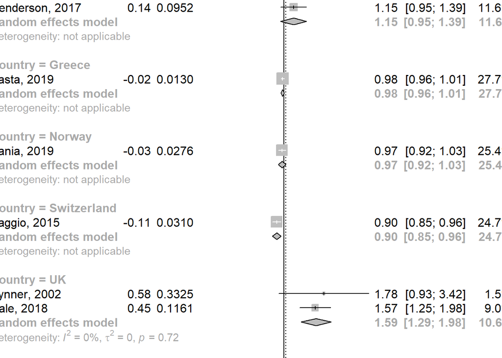

```r
forest(meta.MHdis.Gall.rep0.geo)
```

### DISTRESS - gender

```r
MHdis.Gbg.rep0 <- neet2[which(neet2$Distress==1 & neet2$Gender!="all" & is.na(neet2$Repeated_sample)),]

head(MHdis.Gbg.rep0)
```

|  | X | Study | Country | study_no | Mental.health.measures | Temporality.of.measures | Results | Repeated_sample | MH_measure | MH.measure.included | Gender | OR | LowerCI | UpperCI | OR_ln | lower_ln | upper_ln | SE | LowerCI_sens | UpperCI_sens | Distress | Mood | Anxiety | Behavioral | Alcohol | Cannabis | Drug | Suicidal | Any |
| --- | --- | --- | --- | --- | --- | --- | --- | --- | --- | --- | --- | --- | --- | --- | --- | --- | --- | --- | --- | --- | --- | --- | --- | --- | --- | --- | --- | --- | --- |
| 77 | 8 | Bania, 2019 | Norway | bania 2019 2 | Emotional problems | MH-->NEET | Males: OR 0.88, 95% CI 0.81, 0.97 | NA | distress | NA | boy | 0.88 | 0.81 | 0.97 | -0.12783337 | -0.21072103 | -0.03045921 | 0.04598516 | NA | NA | 1 | 0 | 0 | 0 | 0 | 0 | 0 | 0 | 0 |
| 78 | 9 | Bania, 2019 | Norway | bania 2019 3 | Emotional problems | MH-->NEET | Females: OR 1.04, 95% CI 0.97, 1.11 | NA | distress | NA | girl | 1.04 | 0.97 | 1.11 | 0.03922071 | -0.03045921 | 0.10436002 | 0.03439266 | NA | NA | 1 | 0 | 0 | 0 | 0 | 0 | 0 | 0 | 0 |
| 80 | 15 | Basta, 2019 | Greece | basta 2019 2 | Psychological distress | MHNEET | Males: OR 0.99, 95% CI 0.96, 1.03 | NA | distress | NA | boy | 0.99 | 0.96 | 1.03 | -0.01005034 | -0.04082199 | 0.02955880 | 0.01795429 | NA | NA | 1 | 0 | 0 | 0 | 0 | 0 | 0 | 0 | 0 |
| 81 | 16 | Basta, 2019 | Greece | basta 2019 3 | Psychological distress | MHNEET | Females: OR 0.98, 95% CI 0.95, 1.02 | NA | distress | NA | girl | 0.98 | 0.95 | 1.02 | -0.02020271 | -0.05129329 | 0.01980263 | 0.01813672 | NA | NA | 1 | 0 | 0 | 0 | 0 | 0 | 0 | 0 | 0 |
| 83 | 33 | Bynner, 2002 | UK | bynner 2002 2 | Psychological distress | NEET-->MH | Males: OR 2.20, P>0.05 | NA | distress | NA | boy | 2.20 | 0.86 | 5.63 | 0.78845736 | -0.15082289 | 1.72810944 | 0.47931947 | 1 | 4.85 | 1 | 0 | 0 | 0 | 0 | 0 | 0 | 0 | 0 |
| 84 | 34 | Bynner, 2002 | UK | bynner 2002 3 | Psychological distress | NEET-->MH | Females: OR 1.69, P>0.05 | NA | distress | NA | girl | 1.69 | 0.90 | 3.16 | 0.52472853 | -0.10536052 | 1.15057203 | 0.32039095 | 1 | 2.86 | 1 | 0 | 0 | 0 | 0 | 0 | 0 | 0 | 0 |

```r
meta.MHdis.Gbg.rep0 <- metagen(OR_ln,
                                SE,
                                data=MHdis.Gbg.rep0,
                                studlab=paste(Study),
                                comb.fixed = FALSE,
                                comb.random = TRUE,
                                method.tau = "DL",
                                hakn = FALSE,
                                prediction=FALSE,
                                sm="OR")
meta.MHdis.Gbg.rep0
```

```
##                     OR           95%-CI %W(random)
## Bania, 2019     0.8800 [0.8042; 0.9630]       15.1
## Bania, 2019     1.0400 [0.9722; 1.1125]       17.0
## Basta, 2019     0.9900 [0.9558; 1.0255]       19.2
## Basta, 2019     0.9800 [0.9458; 1.0155]       19.2
## Bynner, 2002    2.2000 [0.8599; 5.6289]        0.5
## Bynner, 2002    1.6900 [0.9019; 3.1667]        1.2
## Hale, 2018      1.7200 [1.2338; 2.3979]        3.7
## Hale, 2018      1.4900 [1.1128; 1.9950]        4.5
## Henderson, 2017 0.9500 [0.7181; 1.2567]        4.8
## Henderson, 2017 1.3300 [1.0054; 1.7594]        4.8
## Henderson, 2017 1.3900 [1.0827; 1.7845]        5.7
## Henderson, 2017 1.0800 [0.8022; 1.4540]        4.4
##
## Number of studies combined: k = 12
##
##                          OR           95%-CI    z p-value
## Random effects model 1.0652 [0.9929; 1.1427] 1.76  0.0783
##
## Quantifying heterogeneity:
## tau^2 = 0.0064; H = 2.01 [1.51; 2.66]; I^2 = 75.1% [56.2%; 85.9%]
##
## Test of heterogeneity:
##      Q d.f.  p-value
##  44.23   11 < 0.0001
##
## Details on meta-analytical method:
## - Inverse variance method
## - DerSimonian-Laird estimator for tau^2
```

```r
meta.MHdis.Gbg.rep0<-update.meta(meta.MHdis.Gbg.rep0,
                                      byvar=Gender,
                                      comb.random = TRUE,
                                      comb.fixed = FALSE)
meta.MHdis.Gbg.rep0
```

```
##                     OR           95%-CI %W(random) Gender
## Bania, 2019     0.8800 [0.8042; 0.9630]       15.1      3
## Bania, 2019     1.0400 [0.9722; 1.1125]       17.0      4
## Basta, 2019     0.9900 [0.9558; 1.0255]       19.2      3
## Basta, 2019     0.9800 [0.9458; 1.0155]       19.2      4
## Bynner, 2002    2.2000 [0.8599; 5.6289]        0.5      3
## Bynner, 2002    1.6900 [0.9019; 3.1667]        1.2      4
## Hale, 2018      1.7200 [1.2338; 2.3979]        3.7      3
## Hale, 2018      1.4900 [1.1128; 1.9950]        4.5      4
## Henderson, 2017 0.9500 [0.7181; 1.2567]        4.8      1
## Henderson, 2017 1.3300 [1.0054; 1.7594]        4.8      1
## Henderson, 2017 1.3900 [1.0827; 1.7845]        5.7      3
## Henderson, 2017 1.0800 [0.8022; 1.4540]        4.4      4
##
## Number of studies combined: k = 12
##
##                          OR           95%-CI    z p-value
## Random effects model 1.0652 [0.9929; 1.1427] 1.76  0.0783
##
## Quantifying heterogeneity:
## tau^2 = 0.0064; H = 2.01 [1.51; 2.66]; I^2 = 75.1% [56.2%; 85.9%]
##
## Quantifying residual heterogeneity:
## H = 2.17 [1.61; 2.93]; I^2 = 78.8% [61.5%; 88.3%]
##
## Test of heterogeneity:
##      Q d.f.  p-value
##  44.23   11 < 0.0001
##
## Results for subgroups (random effects model):
##                 k     OR           95%-CI     Q  tau^2   I^2
## Gender = age    2 1.1241 [0.8083; 1.5631]  2.78 0.0362 64.0%
## Gender = boy    5 1.1338 [0.9554; 1.3456] 27.00 0.0231 85.2%
## Gender = girl   5 1.0646 [0.9633; 1.1765] 12.65 0.0058 68.4%
##
## Test for subgroup differences (random effects model):
##                     Q d.f. p-value
## Between groups   0.44    2  0.8039
##
## Details on meta-analytical method:
## - Inverse variance method
## - DerSimonian-Laird estimator for tau^2
```

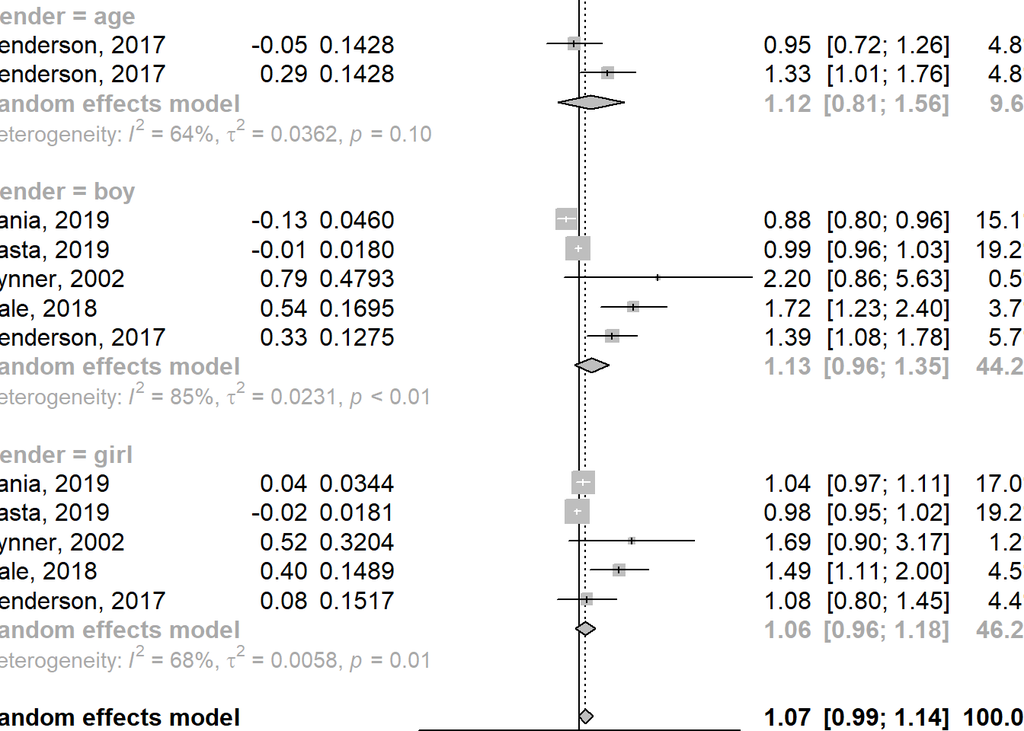

```r
forest(meta.MHdis.Gbg.rep0)
```

## MOOD

mood = 1, gender = all, repeated sample = 0

```r
MHmood.Gall.rep0 <- neet2[which(neet2$Mood==1 & neet2$Gender=="all" & is.na(neet2$Repeated_sample)),]

head(MHmood.Gall.rep0)
```

|  | X | Study | Country | study_no | Mental.health.measures | Temporality.of.measures | Results | Repeated_sample | MH_measure | MH.measure.included | Gender | OR | LowerCI | UpperCI | OR_ln | lower_ln | upper_ln | SE | LowerCI_sens | UpperCI_sens | Distress | Mood | Anxiety | Behavioral | Alcohol | Cannabis | Drug | Suicidal | Any |
| --- | --- | --- | --- | --- | --- | --- | --- | --- | --- | --- | --- | --- | --- | --- | --- | --- | --- | --- | --- | --- | --- | --- | --- | --- | --- | --- | --- | --- | --- |
| 64 | 3 | Baggio, 2015 | Switzerland | baggio 2015 2 | Depressive symptoms | MH-->NEET | OR 1.11, P<0.001 | NA | depression | NA | all | 1.11 | 1.04 | 1.18 | 0.10436002 | 0.03922071 | 0.1655144 | 0.03221779 | NA | NA | 0 | 1 | 0 | 0 | 0 | 0 | 0 | 0 | 0 |
| 65 | 24 | Benjet, 2012 | Mexico | benjet 2012 1 | Mood disorder | MHNEET | OR 2.7, 95% CI 1.8, 4.2 | NA | depression | NA | all | 2.70 | 1.80 | 4.20 | 0.99325177 | 0.58778666 | 1.4350845 | 0.21614741 | NA | NA | 0 | 1 | 0 | 0 | 0 | 0 | 0 | 0 | 0 |
| 66 | 36 | Gariepy, 2018 | Canada | gariepy 2018 1 | Depressive disorder | MHNEET | OR 1.7, 95% CI 1.1, 2.6 | NA | depression | NA | all | 1.70 | 1.10 | 2.60 | 0.53062825 | 0.09531018 | 0.9555114 | 0.21943910 | NA | NA | 0 | 1 | 0 | 0 | 0 | 0 | 0 | 0 | 0 |
| 67 | 44 | Goldman-Mellor, 2016 | UK | goldman 2016 1 | Depressive disorder | MHNEET | OR 1.68, 95% CI 1.33, 2.13 | NA | depression | NA | all | 1.68 | 1.33 | 2.13 | 0.51879379 | 0.28517894 | 0.7561220 | 0.12013853 | NA | NA | 0 | 1 | 0 | 0 | 0 | 0 | 0 | 0 | 0 |
| 73 | 100 | O'Dea, 2014 | Australia | odea 2014 1 | Mood disorder | MHNEET | OR 1.10, 95% CI 1.05,1.15 | NA | depression | NA | all | 1.10 | 1.05 | 1.15 | 0.09531018 | 0.04879016 | 0.1397619 | 0.02320709 | NA | NA | 0 | 1 | 0 | 0 | 0 | 0 | 0 | 0 | 0 |
| 74 | 105 | Power, 2015 | Ireland | power 2015 1 | Depressive disorder (lifetime) | MHNEET | OR NA, P>0.05 | NA | depression | NA | all | NA | NA | NA | NA | NA | NA | NA | NA | NA | 0 | 1 | 0 | 0 | 0 | 0 | 0 | 0 | 0 |

```r
meta.MHmood.Gall.rep0 <- metagen(OR_ln,
                                SE,
                                data=MHmood.Gall.rep0,
                                studlab=paste(Study),
                                comb.fixed = FALSE,
                                comb.random = TRUE,
                                method.tau = "DL",
                                hakn = FALSE,
                                prediction=FALSE,
                                sm="OR")
meta.MHmood.Gall.rep0
```

```
##                          OR           95%-CI %W(random)
## Baggio, 2015         1.1100 [1.0421; 1.1824]       30.8
## Benjet, 2012         2.7000 [1.7676; 4.1243]        9.6
## Gariepy, 2018        1.7000 [1.1058; 2.6136]        9.4
## Goldman-Mellor, 2016 1.6800 [1.3275; 2.1260]       18.7
## O'Dea, 2014          1.1000 [1.0511; 1.1512]       31.6
## Power, 2015              NA                         0.0
##
## Number of studies combined: k = 5
##
##                          OR           95%-CI    z p-value
## Random effects model 1.3555 [1.1593; 1.5848] 3.81  0.0001
##
## Quantifying heterogeneity:
## tau^2 = 0.0196; H = 2.84 [1.94; 4.15]; I^2 = 87.6% [73.4%; 94.2%]
##
## Test of heterogeneity:
##      Q d.f.  p-value
##  32.20    4 < 0.0001
##
## Details on meta-analytical method:
## - Inverse variance method
## - DerSimonian-Laird estimator for tau^2
```

### MOOD - directionality

```r
meta.MHmood.Gall.rep0.dir<-update.meta(meta.MHmood.Gall.rep0,
                                      byvar=Temporality.of.measures,
                                      comb.random = TRUE,
                                      comb.fixed = FALSE)
meta.MHmood.Gall.rep0.dir
```

```
##                          OR           95%-CI %W(random) Temporality.of.measures
## Baggio, 2015         1.1100 [1.0421; 1.1824]       30.8                       1
## Benjet, 2012         2.7000 [1.7676; 4.1243]        9.6                       2
## Gariepy, 2018        1.7000 [1.1058; 2.6136]        9.4                       2
## Goldman-Mellor, 2016 1.6800 [1.3275; 2.1260]       18.7                       2
## O'Dea, 2014          1.1000 [1.0511; 1.1512]       31.6                       2
## Power, 2015              NA                         0.0                       2
##
## Number of studies combined: k = 5
##
##                          OR           95%-CI    z p-value
## Random effects model 1.3555 [1.1593; 1.5848] 3.81  0.0001
##
## Quantifying heterogeneity:
## tau^2 = 0.0196; H = 2.84 [1.94; 4.15]; I^2 = 87.6% [73.4%; 94.2%]
##
## Quantifying residual heterogeneity:
## H = 3.26 [2.18; 4.88]; I^2 = 90.6% [79.0%; 95.8%]
##
## Test of heterogeneity:
##      Q d.f.  p-value
##  32.20    4 < 0.0001
##
## Results for subgroups (random effects model):
##                                        k     OR           95%-CI     Q  tau^2
## Temporality.of.measures = MH-->NEET    1 1.1100 [1.0421; 1.1824]  0.00     --
## Temporality.of.measures = MH<-->NEET   4 1.6503 [1.1149; 2.4428] 31.93 0.1354
##                                        I^2
## Temporality.of.measures = MH-->NEET     --
## Temporality.of.measures = MH<-->NEET 90.6%
##
## Test for subgroup differences (random effects model):
##                     Q d.f. p-value
## Between groups   3.83    1  0.0504
##
## Details on meta-analytical method:
## - Inverse variance method
## - DerSimonian-Laird estimator for tau^2
```

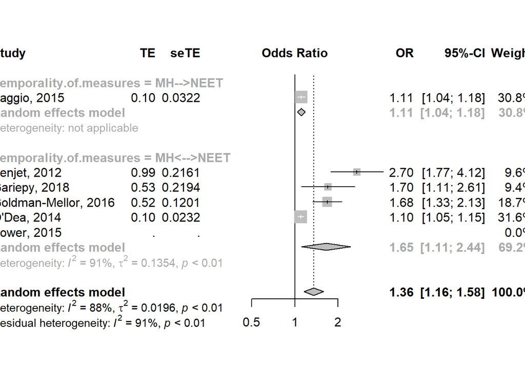

```r
forest(meta.MHmood.Gall.rep0.dir)
```

### MOOD - geography

```r
meta.MHmood.Gall.rep0.geo<-update.meta(meta.MHmood.Gall.rep0,
                                      byvar=Country,
                                      comb.random = TRUE,
                                      comb.fixed = FALSE)
meta.MHmood.Gall.rep0.geo
```

```
##                          OR           95%-CI %W(random) Country
## Baggio, 2015         1.1100 [1.0421; 1.1824]       30.8       7
## Benjet, 2012         2.7000 [1.7676; 4.1243]        9.6       5
## Gariepy, 2018        1.7000 [1.1058; 2.6136]        9.4       2
## Goldman-Mellor, 2016 1.6800 [1.3275; 2.1260]       18.7       8
## O'Dea, 2014          1.1000 [1.0511; 1.1512]       31.6       1
## Power, 2015              NA                         0.0       4
##
## Number of studies combined: k = 5
##
##                          OR           95%-CI    z p-value
## Random effects model 1.3555 [1.1593; 1.5848] 3.81  0.0001
##
## Quantifying heterogeneity:
## tau^2 = 0.0196; H = 2.84 [1.94; 4.15]; I^2 = 87.6% [73.4%; 94.2%]
##
## Test of heterogeneity:
##      Q d.f.  p-value
##  32.20    4 < 0.0001
##
## Results for subgroups (random effects model):
##                         k     OR           95%-CI    Q tau^2 I^2
## Country = Australia     1 1.1000 [1.0511; 1.1512] 0.00    --  --
## Country = Canada        1 1.7000 [1.1058; 2.6136] 0.00    --  --
## Country = Ireland       0     NA                    --    --  --
## Country = Mexico        1 2.7000 [1.7676; 4.1243] 0.00    --  --
## Country = Switzerland   1 1.1100 [1.0421; 1.1824] 0.00    --  --
## Country = UK            1 1.6800 [1.3275; 2.1260] 0.00    --  --
##
## Test for subgroup differences (random effects model):
##                      Q d.f.  p-value
## Between groups   32.20    4 < 0.0001
##
## Details on meta-analytical method:
## - Inverse variance method
## - DerSimonian-Laird estimator for tau^2
```

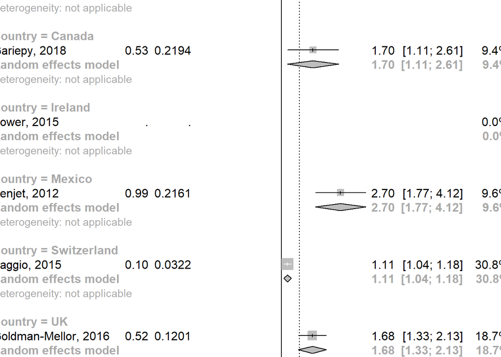

```r
forest(meta.MHmood.Gall.rep0.geo)
```

### MOOD - gender

```r
MHmood.Gbg.rep0 <- neet2[which(neet2$Mood==1 & neet2$Gender!="all" & is.na(neet2$Repeated_sample)),]

head(MHmood.Gbg.rep0)
```

| X | Study | Country | study_no | Mental.health.measures | Temporality.of.measures | Results | Repeated_sample | MH_measure | MH.measure.included | Gender | OR | LowerCI | UpperCI | OR_ln | lower_ln | upper_ln | SE | LowerCI_sens | UpperCI_sens | Distress | Mood | Anxiety | Behavioral | Alcohol | Cannabis | Drug | Suicidal | Any |
| --- | --- | --- | --- | --- | --- | --- | --- | --- | --- | --- | --- | --- | --- | --- | --- | --- | --- | --- | --- | --- | --- | --- | --- | --- | --- | --- | --- | --- |

## ANXIETY

anxiety = 1, gender = all, repeated sample = 0

```r
MHanx.Gall.rep0 <- neet2[which(neet2$Anxiety==1 & neet2$Gender=="all" & is.na(neet2$Repeated_sample)),]

head(MHanx.Gall.rep0)
```

|  | X | Study | Country | study_no | Mental.health.measures | Temporality.of.measures | Results | Repeated_sample | MH_measure | MH.measure.included | Gender | OR | LowerCI | UpperCI | OR_ln | lower_ln | upper_ln | SE | LowerCI_sens | UpperCI_sens | Distress | Mood | Anxiety | Behavioral | Alcohol | Cannabis | Drug | Suicidal | Any |
| --- | --- | --- | --- | --- | --- | --- | --- | --- | --- | --- | --- | --- | --- | --- | --- | --- | --- | --- | --- | --- | --- | --- | --- | --- | --- | --- | --- | --- | --- |
| 51 | 17 | Basta, 2019 | Greece | basta 2019 4 | Anxiety symptoms | MHNEET | All: OR 1.03, 95% CI 0.99, 1.06 | NA | anxiety | NA | all | 1.03 | 0.99 | 1.06 | 0.0295588 | -0.01005034 | 0.05826891 | 0.01742838 | NA | NA | 0 | 0 | 1 | 0 | 0 | 0 | 0 | 0 | 0 |
| 54 | 25 | Benjet, 2012 | Mexico | benjet 2012 2 | Anxiety disorder | MHNEET | OR 1.3, 95% CI 0.9, 1.8 | NA | anxiety | NA | all | 1.30 | 0.90 | 1.80 | 0.2623643 | -0.10536052 | 0.58778666 | 0.17682326 | NA | NA | 0 | 0 | 1 | 0 | 0 | 0 | 0 | 0 | 0 |
| 55 | 38 | Gariepy, 2018 | Canada | gariepy 2018 3 | Generalized anxiety disorder | MHNEET | OR 2.6, 95% CI 1.4, 5.1 | NA | anxiety | NA | all | 2.60 | 1.40 | 5.10 | 0.9555114 | 0.33647224 | 1.62924054 | 0.32978783 | NA | NA | 0 | 0 | 1 | 0 | 0 | 0 | 0 | 0 | 0 |
| 56 | 45 | Goldman-Mellor, 2016 | UK | goldman 2016 2 | Generalized anxiety disorder | MHNEET | OR 1.84, 95% CI 1.19, 2.86 | NA | anxiety | NA | all | 1.84 | 1.19 | 2.86 | 0.6097656 | 0.17395331 | 1.05082162 | 0.22369090 | NA | NA | 0 | 0 | 1 | 0 | 0 | 0 | 0 | 0 | 0 |
| 62 | 101 | O'Dea, 2014 | Australia | odea 2014 2 | Anxiety disorder | MHNEET | OR NA, P>0.05 | NA | anxiety | NA | all | NA | NA | NA | NA | NA | NA | NA | NA | NA | 0 | 0 | 1 | 0 | 0 | 0 | 0 | 0 | 0 |
| 63 | 106 | Power, 2015 | Ireland | power 2015 2 | Anxiety disorder (lifetime) | MHNEET | OR 2.4, 95% CI 1.0, 5.9 | NA | anxiety | NA | all | 2.40 | 1.00 | 5.90 | 0.8754687 | 0.00000000 | 1.77495235 | 0.45279397 | NA | NA | 0 | 0 | 1 | 0 | 0 | 0 | 0 | 0 | 0 |

```r
meta.MHanx.Gall.rep0 <- metagen(OR_ln,
                                 SE,
                                 data=MHanx.Gall.rep0,
                                 studlab=paste(Study),
                                 comb.fixed = FALSE,
                                 comb.random = TRUE,
                                 method.tau = "DL",
                                 hakn = FALSE,
                                 prediction=FALSE,
                                 sm="OR")
meta.MHanx.Gall.rep0
```

```
##                          OR           95%-CI %W(random)
## Basta, 2019          1.0300 [0.9954; 1.0658]       29.5
## Benjet, 2012         1.3000 [0.9192; 1.8385]       23.4
## Gariepy, 2018        2.6000 [1.3623; 4.9624]       15.4
## Goldman-Mellor, 2016 1.8400 [1.1869; 2.8525]       20.8
## O'Dea, 2014              NA                         0.0
## Power, 2015          2.4000 [0.9881; 5.8295]       10.9
##
## Number of studies combined: k = 5
##
##                          OR           95%-CI    z p-value
## Random effects model 1.5523 [1.0746; 2.2425] 2.34  0.0191
##
## Quantifying heterogeneity:
## tau^2 = 0.1192; H = 2.21 [1.44; 3.40]; I^2 = 79.5% [51.5%; 91.4%]
##
## Test of heterogeneity:
##      Q d.f. p-value
##  19.54    4  0.0006
##
## Details on meta-analytical method:
## - Inverse variance method
## - DerSimonian-Laird estimator for tau^2
```

### ANXIETY - directionality

```r
meta.MHanx.Gall.rep0.dir<-update.meta(meta.MHanx.Gall.rep0,
                                       byvar=Temporality.of.measures,
                                       comb.random = TRUE,
                                       comb.fixed = FALSE)
meta.MHanx.Gall.rep0.dir
```

```
##                          OR           95%-CI %W(random) Temporality.of.measures
## Basta, 2019          1.0300 [0.9954; 1.0658]       29.5                       2
## Benjet, 2012         1.3000 [0.9192; 1.8385]       23.4                       2
## Gariepy, 2018        2.6000 [1.3623; 4.9624]       15.4                       2
## Goldman-Mellor, 2016 1.8400 [1.1869; 2.8525]       20.8                       2
## O'Dea, 2014              NA                         0.0                       2
## Power, 2015          2.4000 [0.9881; 5.8295]       10.9                       2
##
## Number of studies combined: k = 5
##
##                          OR           95%-CI    z p-value
## Random effects model 1.5523 [1.0746; 2.2425] 2.34  0.0191
##
## Quantifying heterogeneity:
## tau^2 = 0.1192; H = 2.21 [1.44; 3.40]; I^2 = 79.5% [51.5%; 91.4%]
##
## Quantifying residual heterogeneity:
## H = 2.21 [1.44; 3.40]; I^2 = 79.5% [51.5%; 91.4%]
##
## Test of heterogeneity:
##      Q d.f. p-value
##  19.54    4  0.0006
##
## Results for subgroups (random effects model):
##                                        k     OR           95%-CI     Q  tau^2
## Temporality.of.measures = MH<-->NEET   5 1.5523 [1.0746; 2.2425] 19.54 0.1192
##                                        I^2
## Temporality.of.measures = MH<-->NEET 79.5%
##
## Test for subgroup differences (random effects model):
##                     Q d.f. p-value
## Between groups   0.00    0      --
##
## Details on meta-analytical method:
## - Inverse variance method
## - DerSimonian-Laird estimator for tau^2
```

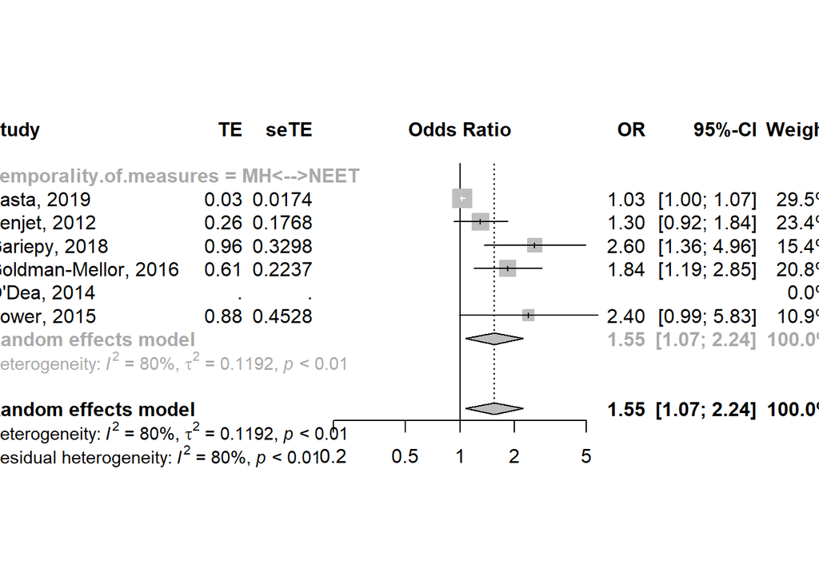

```r
forest(meta.MHanx.Gall.rep0.dir)
```

### ANXIETY - geography

```r
meta.MHanx.Gall.rep0.geo<-update.meta(meta.MHanx.Gall.rep0,
                                       byvar=Country,
                                       comb.random = TRUE,
                                       comb.fixed = FALSE)
meta.MHanx.Gall.rep0.geo
```

```
##                          OR           95%-CI %W(random) Country
## Basta, 2019          1.0300 [0.9954; 1.0658]       29.5       3
## Benjet, 2012         1.3000 [0.9192; 1.8385]       23.4       5
## Gariepy, 2018        2.6000 [1.3623; 4.9624]       15.4       2
## Goldman-Mellor, 2016 1.8400 [1.1869; 2.8525]       20.8       8
## O'Dea, 2014              NA                         0.0       1
## Power, 2015          2.4000 [0.9881; 5.8295]       10.9       4
##
## Number of studies combined: k = 5
##
##                          OR           95%-CI    z p-value
## Random effects model 1.5523 [1.0746; 2.2425] 2.34  0.0191
##
## Quantifying heterogeneity:
## tau^2 = 0.1192; H = 2.21 [1.44; 3.40]; I^2 = 79.5% [51.5%; 91.4%]
##
## Test of heterogeneity:
##      Q d.f. p-value
##  19.54    4  0.0006
##
## Results for subgroups (random effects model):
##                       k     OR           95%-CI    Q tau^2 I^2
## Country = Australia   0     NA                    --    --  --
## Country = Canada      1 2.6000 [1.3623; 4.9624] 0.00    --  --
## Country = Greece      1 1.0300 [0.9954; 1.0658] 0.00    --  --
## Country = Ireland     1 2.4000 [0.9881; 5.8295] 0.00    --  --
## Country = Mexico      1 1.3000 [0.9192; 1.8385] 0.00    --  --
## Country = UK          1 1.8400 [1.1869; 2.8525] 0.00    --  --
##
## Test for subgroup differences (random effects model):
##                      Q d.f. p-value
## Between groups   19.54    4  0.0006
##
## Details on meta-analytical method:
## - Inverse variance method
## - DerSimonian-Laird estimator for tau^2
```

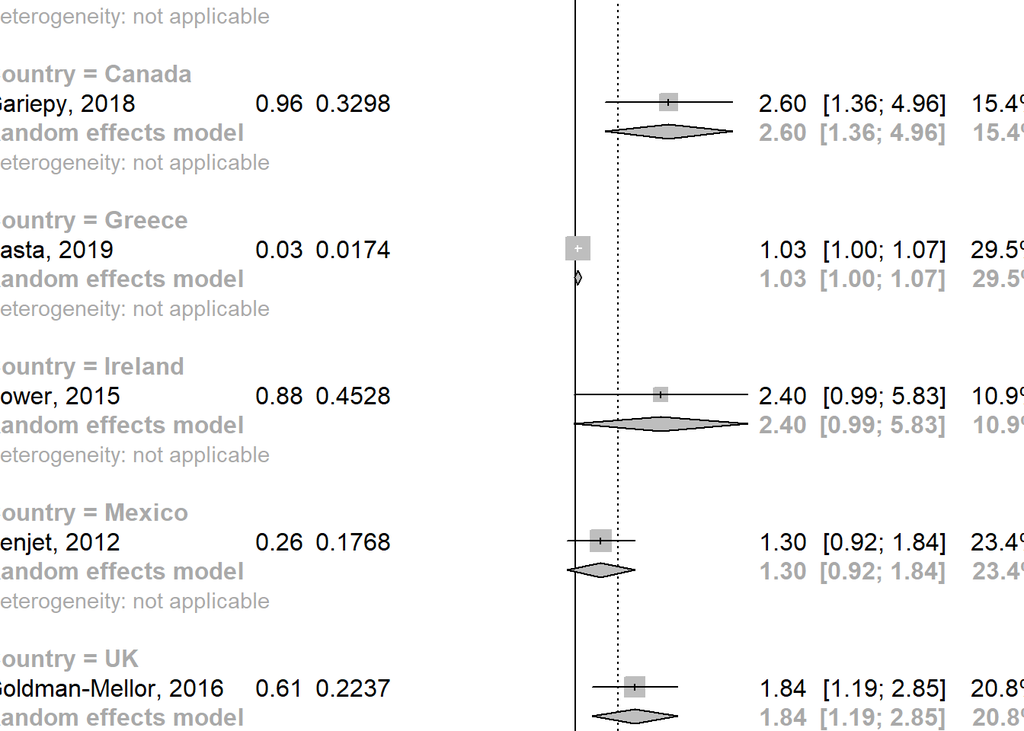

```r
forest(meta.MHanx.Gall.rep0.geo)
```

### ANXIETY - gender

```r
MHanx.Gbg.rep0 <- neet2[which(neet2$Anxiety==1 & neet2$Gender!="all" & is.na(neet2$Repeated_sample)),]

head(MHanx.Gbg.rep0)
```

|  | X | Study | Country | study_no | Mental.health.measures | Temporality.of.measures | Results | Repeated_sample | MH_measure | MH.measure.included | Gender | OR | LowerCI | UpperCI | OR_ln | lower_ln | upper_ln | SE | LowerCI_sens | UpperCI_sens | Distress | Mood | Anxiety | Behavioral | Alcohol | Cannabis | Drug | Suicidal | Any |
| --- | --- | --- | --- | --- | --- | --- | --- | --- | --- | --- | --- | --- | --- | --- | --- | --- | --- | --- | --- | --- | --- | --- | --- | --- | --- | --- | --- | --- | --- |
| 52 | 18 | Basta, 2019 | Greece | basta 2019 5 | Anxiety symptoms | MHNEET | Males: OR 1.01, 95% CI 0.96, 1.03 | NA | anxiety | NA | boy | 1.01 | 0.96 | 1.03 | 0.009950331 | -0.040821995 | 0.02955880 | 0.01795429 | NA | NA | 0 | 0 | 1 | 0 | 0 | 0 | 0 | 0 | 0 |
| 53 | 19 | Basta, 2019 | Greece | basta 2019 6 | Anxiety symptoms | MHNEET | Females: OR 1.05, 95% CI 1.01, 1.10 | NA | anxiety | NA | girl | 1.05 | 1.01 | 1.10 | 0.048790164 | 0.009950331 | 0.09531018 | 0.02177547 | NA | NA | 0 | 0 | 1 | 0 | 0 | 0 | 0 | 0 | 0 |

```r
meta.MHanx.Gbg.rep0 <- metagen(OR_ln,
                               SE,
                               data=MHanx.Gbg.rep0,
                               studlab=paste(Study),
                               comb.fixed = FALSE,
                               comb.random = TRUE,
                               method.tau = "DL",
                               hakn = FALSE,
                               prediction=FALSE,
                               sm="OR")
meta.MHanx.Gbg.rep0
```

```
##                 OR           95%-CI %W(random)
## Basta, 2019 1.0100 [0.9751; 1.0462]       55.0
## Basta, 2019 1.0500 [1.0061; 1.0958]       45.0
##
## Number of studies combined: k = 2
##
##                          OR           95%-CI    z p-value
## Random effects model 1.0278 [0.9896; 1.0675] 1.42  0.1559
##
## Quantifying heterogeneity:
## tau^2 = 0.0004; H = 1.38; I^2 = 47.2%
##
## Test of heterogeneity:
##     Q d.f. p-value
##  1.89    1  0.1688
##
## Details on meta-analytical method:
## - Inverse variance method
## - DerSimonian-Laird estimator for tau^2
```

```r
meta.MHanx.Gbg.rep0<-update.meta(meta.MHanx.Gbg.rep0,
                                 byvar=Gender,
                                 comb.random = TRUE,
                                 comb.fixed = FALSE)
meta.MHanx.Gbg.rep0
```

```
##                 OR           95%-CI %W(random) Gender
## Basta, 2019 1.0100 [0.9751; 1.0462]       55.0      3
## Basta, 2019 1.0500 [1.0061; 1.0958]       45.0      4
##
## Number of studies combined: k = 2
##
##                          OR           95%-CI    z p-value
## Random effects model 1.0278 [0.9896; 1.0675] 1.42  0.1559
##
## Quantifying heterogeneity:
## tau^2 = 0.0004; H = 1.38; I^2 = 47.2%
##
## Test of heterogeneity:
##     Q d.f. p-value
##  1.89    1  0.1688
##
## Results for subgroups (random effects model):
##                 k     OR           95%-CI    Q tau^2 I^2
## Gender = boy    1 1.0100 [0.9751; 1.0462] 0.00    --  --
## Gender = girl   1 1.0500 [1.0061; 1.0958] 0.00    --  --
##
## Test for subgroup differences (random effects model):
##                     Q d.f. p-value
## Between groups   1.89    1  0.1688
##
## Details on meta-analytical method:
## - Inverse variance method
## - DerSimonian-Laird estimator for tau^2
```

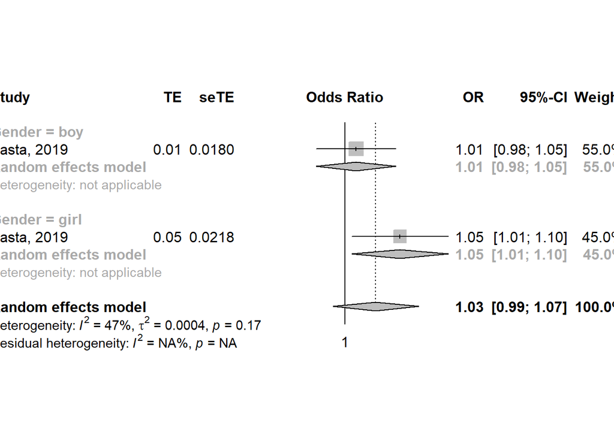

```r
forest(meta.MHanx.Gbg.rep0)
```

## BEHAVIOURAL

behavioural = 1, gender = all, repeated sample = 0

```r
MHbeh.Gall.rep0 <- neet2[which(neet2$Behavioral==1 & neet2$Gender=="all" & is.na(neet2$Repeated_sample)),]

head(MHbeh.Gall.rep0)
```

|  | X | Study | Country | study_no | Mental.health.measures | Temporality.of.measures | Results | Repeated_sample | MH_measure | MH.measure.included | Gender | OR | LowerCI | UpperCI | OR_ln | lower_ln | upper_ln | SE | LowerCI_sens | UpperCI_sens | Distress | Mood | Anxiety | Behavioral | Alcohol | Cannabis | Drug | Suicidal | Any |
| --- | --- | --- | --- | --- | --- | --- | --- | --- | --- | --- | --- | --- | --- | --- | --- | --- | --- | --- | --- | --- | --- | --- | --- | --- | --- | --- | --- | --- | --- |
| 38 | 10 | Bania, 2019 | Norway | bania 2019 4 | Conduct problems | MH-->NEET | calculated | NA | behavioral | NA | all | 1.221 | 1.157 | 1.284 | 0.1996702 | 0.1458304 | 0.24998021 | 0.02656882 | NA | NA | 0 | 0 | 0 | 1 | 0 | 0 | 0 | 0 | 0 |
| 41 | 27 | Benjet, 2012 | Mexico | benjet 2012 4 | Behavioral disorder | MHNEET | OR 2.1, 95% CI 1.5, 2.8 | NA | behavioral | NA | all | 2.100 | 1.500 | 2.800 | 0.7419373 | 0.4054651 | 1.02961942 | 0.15922304 | NA | NA | 0 | 0 | 0 | 1 | 0 | 0 | 0 | 0 | 0 |
| 42 | 48 | Goldman-Mellor, 2016 | UK | goldman 2016 5 | Conduct disorder | MHNEET | OR 1.46, 95% CI 1.12, 1.89 | NA | behavioral | NA | all | 1.460 | 1.120 | 1.890 | 0.3784364 | 0.1133287 | 0.63657683 | 0.13348167 | NA | NA | 0 | 0 | 0 | 1 | 0 | 0 | 0 | 0 | 0 |
| 45 | 83 | Henderson, 2017 | Canada | henderson 2017 6 | Externalizing disorders | MHNEET | Total: OR 0.90, 95% CI 0.76, 1.08 | NA | behavioral | NA | all | 0.900 | 0.760 | 1.080 | -0.1053605 | -0.2744368 | 0.07696104 | 0.08964232 | NA | NA | 0 | 0 | 0 | 1 | 0 | 0 | 0 | 0 | 0 |
| 50 | 118 | Rodwell, 2018 | Australia | rodwell 2018 2 | Disruptive behaviour disorder | MH-->NEET | OR 1.71, 95% CI 1.15, 2.55 | NA | behavioral | NA | all | 1.710 | 1.150 | 2.550 | 0.5364934 | 0.1397619 | 0.93609336 | 0.20314577 | NA | NA | 0 | 0 | 0 | 1 | 0 | 0 | 0 | 0 | 0 |

```r
meta.MHbeh.Gall.rep0 <- metagen(OR_ln,
                                SE,
                                data=MHbeh.Gall.rep0,
                                studlab=paste(Study),
                                comb.fixed = FALSE,
                                comb.random = TRUE,
                                method.tau = "DL",
                                hakn = FALSE,
                                prediction=FALSE,
                                sm="OR")
meta.MHbeh.Gall.rep0
```

```
##                          OR           95%-CI %W(random)
## Bania, 2019          1.2210 [1.1590; 1.2863]       25.6
## Benjet, 2012         2.1000 [1.5371; 2.8691]       17.6
## Goldman-Mellor, 2016 1.4600 [1.1239; 1.8966]       19.5
## Henderson, 2017      0.9000 [0.7550; 1.0729]       22.6
## Rodwell, 2018        1.7100 [1.1484; 2.5463]       14.7
##
## Number of studies combined: k = 5
##
##                          OR           95%-CI    z p-value
## Random effects model 1.3645 [1.0823; 1.7204] 2.63  0.0086
##
## Quantifying heterogeneity:
## tau^2 = 0.0539; H = 2.63 [1.77; 3.91]; I^2 = 85.6% [68.2%; 93.5%]
##
## Test of heterogeneity:
##      Q d.f.  p-value
##  27.72    4 < 0.0001
##
## Details on meta-analytical method:
## - Inverse variance method
## - DerSimonian-Laird estimator for tau^2
```

### BEHAVIOURAL - directionality

```r
meta.MHbeh.Gall.rep0.dir<-update.meta(meta.MHbeh.Gall.rep0,
                                      byvar=Temporality.of.measures,
                                      comb.random = TRUE,
                                      comb.fixed = FALSE)
meta.MHbeh.Gall.rep0.dir
```

```
##                          OR           95%-CI %W(random) Temporality.of.measures
## Bania, 2019          1.2210 [1.1590; 1.2863]       25.6                       1
## Benjet, 2012         2.1000 [1.5371; 2.8691]       17.6                       2
## Goldman-Mellor, 2016 1.4600 [1.1239; 1.8966]       19.5                       2
## Henderson, 2017      0.9000 [0.7550; 1.0729]       22.6                       2
## Rodwell, 2018        1.7100 [1.1484; 2.5463]       14.7                       1
##
## Number of studies combined: k = 5
##
##                          OR           95%-CI    z p-value
## Random effects model 1.3645 [1.0823; 1.7204] 2.63  0.0086
##
## Quantifying heterogeneity:
## tau^2 = 0.0539; H = 2.63 [1.77; 3.91]; I^2 = 85.6% [68.2%; 93.5%]
##
## Quantifying residual heterogeneity:
## H = 3.03 [1.99; 4.60]; I^2 = 89.1% [74.8%; 95.3%]
##
## Test of heterogeneity:
##      Q d.f.  p-value
##  27.72    4 < 0.0001
##
## Results for subgroups (random effects model):
##                                        k     OR           95%-CI     Q  tau^2
## Temporality.of.measures = MH-->NEET    2 1.3605 [0.9996; 1.8517]  2.70 0.0357
## Temporality.of.measures = MH<-->NEET   3 1.3849 [0.8409; 2.2809] 24.78 0.1776
##                                        I^2
## Temporality.of.measures = MH-->NEET  63.0%
## Temporality.of.measures = MH<-->NEET 91.9%
##
## Test for subgroup differences (random effects model):
##                     Q d.f. p-value
## Between groups   0.00    1  0.9527
##
## Details on meta-analytical method:
## - Inverse variance method
## - DerSimonian-Laird estimator for tau^2
```

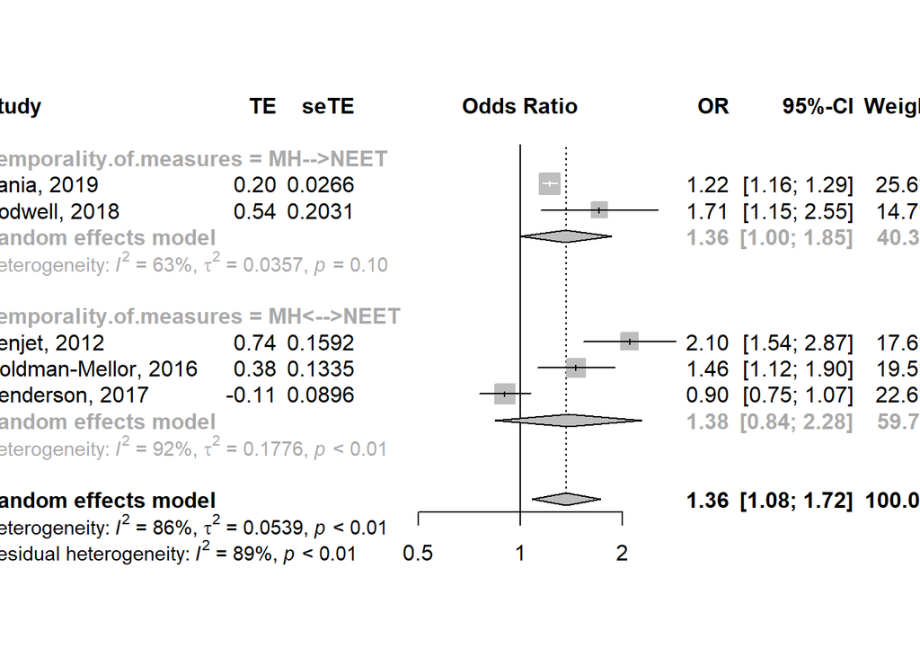

```r
forest(meta.MHbeh.Gall.rep0.dir)
```

### BEHAVIOURAL - geography

```r
meta.MHbeh.Gall.rep0.geo<-update.meta(meta.MHbeh.Gall.rep0,
                                      byvar=Country,
                                      comb.random = TRUE,
                                      comb.fixed = FALSE)
meta.MHbeh.Gall.rep0.geo
```

```
##                          OR           95%-CI %W(random) Country
## Bania, 2019          1.2210 [1.1590; 1.2863]       25.6       6
## Benjet, 2012         2.1000 [1.5371; 2.8691]       17.6       5
## Goldman-Mellor, 2016 1.4600 [1.1239; 1.8966]       19.5       8
## Henderson, 2017      0.9000 [0.7550; 1.0729]       22.6       2
## Rodwell, 2018        1.7100 [1.1484; 2.5463]       14.7       1
##
## Number of studies combined: k = 5
##
##                          OR           95%-CI    z p-value
## Random effects model 1.3645 [1.0823; 1.7204] 2.63  0.0086
##
## Quantifying heterogeneity:
## tau^2 = 0.0539; H = 2.63 [1.77; 3.91]; I^2 = 85.6% [68.2%; 93.5%]
##
## Test of heterogeneity:
##      Q d.f.  p-value
##  27.72    4 < 0.0001
##
## Results for subgroups (random effects model):
##                       k     OR           95%-CI    Q tau^2 I^2
## Country = Australia   1 1.7100 [1.1484; 2.5463] 0.00    --  --
## Country = Canada      1 0.9000 [0.7550; 1.0729] 0.00    --  --
## Country = Mexico      1 2.1000 [1.5371; 2.8691] 0.00    --  --
## Country = Norway      1 1.2210 [1.1590; 1.2863] 0.00    --  --
## Country = UK          1 1.4600 [1.1239; 1.8966] 0.00    --  --
##
## Test for subgroup differences (random effects model):
##                      Q d.f.  p-value
## Between groups   27.72    4 < 0.0001
##
## Details on meta-analytical method:
## - Inverse variance method
## - DerSimonian-Laird estimator for tau^2
```

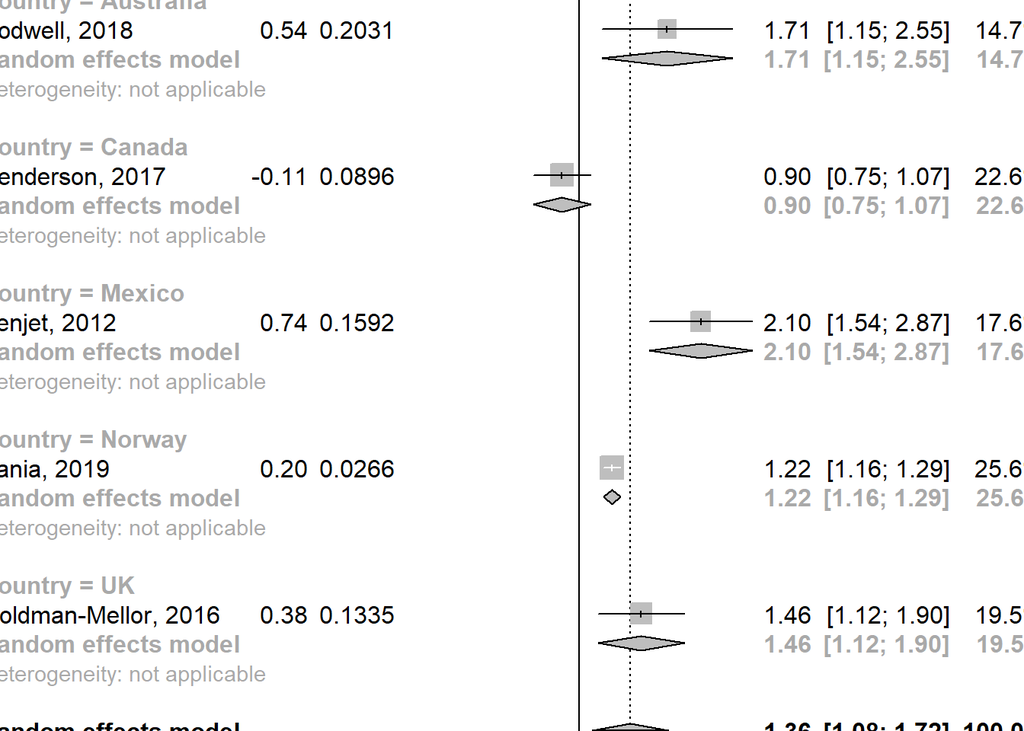

```r
forest(meta.MHbeh.Gall.rep0.geo)
```

### BEHAVIOURAL - gender

```r
MHbeh.Gbg.rep0 <- neet2[which(neet2$Behavioral==1 & neet2$Gender!="all" & is.na(neet2$Repeated_sample)),]

head(MHbeh.Gbg.rep0)
```

|  | X | Study | Country | study_no | Mental.health.measures | Temporality.of.measures | Results | Repeated_sample | MH_measure | MH.measure.included | Gender | OR | LowerCI | UpperCI | OR_ln | lower_ln | upper_ln | SE | LowerCI_sens | UpperCI_sens | Distress | Mood | Anxiety | Behavioral | Alcohol | Cannabis | Drug | Suicidal | Any |
| --- | --- | --- | --- | --- | --- | --- | --- | --- | --- | --- | --- | --- | --- | --- | --- | --- | --- | --- | --- | --- | --- | --- | --- | --- | --- | --- | --- | --- | --- |
| 39 | 11 | Bania, 2019 | Norway | bania 2019 5 | Conduct problems | MH-->NEET | Males: OR 1.17, 95% CI 1.07, 1.28 | NA | behavioral | NA | boy | 1.17 | 1.07 | 1.28 | 0.15700375 | 0.06765865 | 0.2468601 | 0.04571465 | NA | NA | 0 | 0 | 0 | 1 | 0 | 0 | 0 | 0 | 0 |
| 40 | 12 | Bania, 2019 | Norway | bania 2019 6 | Conduct problems | MH-->NEET | Females: OR 1.25, 95% CI 1.17, 1.33 | NA | behavioral | NA | girl | 1.25 | 1.17 | 1.33 | 0.22314355 | 0.15700375 | 0.2851789 | 0.03269775 | NA | NA | 0 | 0 | 0 | 1 | 0 | 0 | 0 | 0 | 0 |
| 46 | 84 | Henderson, 2017 | Canada | henderson 2017 7 | Externalizing disorders | MHNEET | Age<18: OR 1.18, 95% CI 0.90, 1.56 | NA | behavioral | NA | age | 1.18 | 0.90 | 1.56 | 0.16551444 | -0.10536052 | 0.4446858 | 0.14031794 | NA | NA | 0 | 0 | 0 | 1 | 0 | 0 | 0 | 0 | 0 |
| 47 | 85 | Henderson, 2017 | Canada | henderson 2017 8 | Externalizing disorders | MHNEET | Age=18: OR 1.13, 95% CI 0.87, 1.46 | NA | behavioral | NA | age | 1.13 | 0.87 | 1.46 | 0.12221763 | -0.13926207 | 0.3784364 | 0.13206594 | NA | NA | 0 | 0 | 0 | 1 | 0 | 0 | 0 | 0 | 0 |
| 48 | 86 | Henderson, 2017 | Canada | henderson 2017 9 | Externalizing disorders | MHNEET | Boys: OR 0.93, 95% CI 0.73, 1.19 | NA | behavioral | NA | boy | 0.93 | 0.73 | 1.19 | -0.07257069 | -0.31471075 | 0.1739533 | 0.12465920 | NA | NA | 0 | 0 | 0 | 1 | 0 | 0 | 0 | 0 | 0 |
| 49 | 87 | Henderson, 2017 | Canada | henderson 2017 10 | Externalizing disorders | MHNEET | Girls: OR 0.87, 95% CI 0.67, 1.12 | NA | behavioral | NA | girl | 0.87 | 0.67 | 1.12 | -0.13926207 | -0.40047757 | 0.1133287 | 0.13107302 | NA | NA | 0 | 0 | 0 | 1 | 0 | 0 | 0 | 0 | 0 |

```r
meta.MHbeh.Gbg.rep0 <- metagen(OR_ln,
                               SE,
                               data=MHbeh.Gbg.rep0,
                               studlab=paste(Study),
                               comb.fixed = FALSE,
                               comb.random = TRUE,
                               method.tau = "DL",
                               hakn = FALSE,
                               prediction=FALSE,
                               sm="OR")
meta.MHbeh.Gbg.rep0
```

```
##                     OR           95%-CI %W(random)
## Bania, 2019     1.1700 [1.0697; 1.2797]       27.4
## Bania, 2019     1.2500 [1.1724; 1.3327]       30.6
## Henderson, 2017 1.1800 [0.8963; 1.5535]        9.6
## Henderson, 2017 1.1300 [0.8723; 1.4638]       10.5
## Henderson, 2017 0.9300 [0.7284; 1.1874]       11.3
## Henderson, 2017 0.8700 [0.6729; 1.1248]       10.6
##
## Number of studies combined: k = 6
##
##                          OR           95%-CI    z p-value
## Random effects model 1.1242 [1.0171; 1.2425] 2.29  0.0219
##
## Quantifying heterogeneity:
## tau^2 = 0.0074; H = 1.56 [1.00; 2.45]; I^2 = 58.9% [0.0%; 83.3%]
##
## Test of heterogeneity:
##      Q d.f. p-value
##  12.18    5  0.0324
##
## Details on meta-analytical method:
## - Inverse variance method
## - DerSimonian-Laird estimator for tau^2
```

```r
meta.MHbeh.Gbg.rep0<-update.meta(meta.MHbeh.Gbg.rep0,
                                 byvar=Gender,
                                 comb.random = TRUE,
                                 comb.fixed = FALSE)
meta.MHbeh.Gbg.rep0
```

```
##                     OR           95%-CI %W(random) Gender
## Bania, 2019     1.1700 [1.0697; 1.2797]       27.4      3
## Bania, 2019     1.2500 [1.1724; 1.3327]       30.6      4
## Henderson, 2017 1.1800 [0.8963; 1.5535]        9.6      1
## Henderson, 2017 1.1300 [0.8723; 1.4638]       10.5      1
## Henderson, 2017 0.9300 [0.7284; 1.1874]       11.3      3
## Henderson, 2017 0.8700 [0.6729; 1.1248]       10.6      4
##
## Number of studies combined: k = 6
##
##                          OR           95%-CI    z p-value
## Random effects model 1.1242 [1.0171; 1.2425] 2.29  0.0219
##
## Quantifying heterogeneity:
## tau^2 = 0.0074; H = 1.56 [1.00; 2.45]; I^2 = 58.9% [0.0%; 83.3%]
##
## Quantifying residual heterogeneity:
## H = 1.85 [1.09; 3.12]; I^2 = 70.7% [16.2%; 89.8%]
##
## Test of heterogeneity:
##      Q d.f. p-value
##  12.18    5  0.0324
##
## Results for subgroups (random effects model):
##                 k     OR           95%-CI    Q  tau^2   I^2
## Gender = age    2 1.1532 [0.9551; 1.3924] 0.05      0  0.0%
## Gender = boy    2 1.0741 [0.8641; 1.3351] 2.99 0.0175 66.5%
## Gender = girl   2 1.0663 [0.7495; 1.5169] 7.20 0.0565 86.1%
##
## Test for subgroup differences (random effects model):
##                     Q d.f. p-value
## Between groups   0.30    2  0.8628
##
## Details on meta-analytical method:
## - Inverse variance method
## - DerSimonian-Laird estimator for tau^2
```

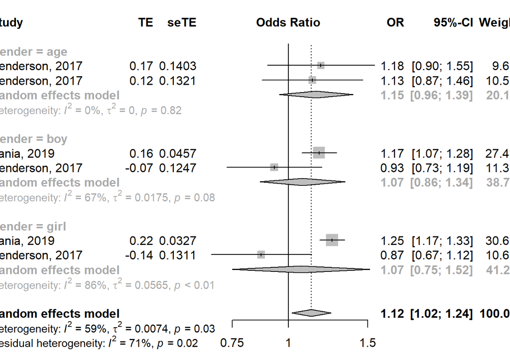

```r
forest(meta.MHbeh.Gbg.rep0)
```

## ALCOHOL

alcohol = 1, gender = all, repeated sample = 0

```r
MHalc.Gall.rep0 <- neet2[which(neet2$Alcohol==1 & neet2$Gender=="all" & is.na(neet2$Repeated_sample)),]

head(MHalc.Gall.rep0)
```

|  | X | Study | Country | study_no | Mental.health.measures | Temporality.of.measures | Results | Repeated_sample | MH_measure | MH.measure.included | Gender | OR | LowerCI | UpperCI | OR_ln | lower_ln | upper_ln | SE | LowerCI_sens | UpperCI_sens | Distress | Mood | Anxiety | Behavioral | Alcohol | Cannabis | Drug | Suicidal | Any |
| --- | --- | --- | --- | --- | --- | --- | --- | --- | --- | --- | --- | --- | --- | --- | --- | --- | --- | --- | --- | --- | --- | --- | --- | --- | --- | --- | --- | --- | --- |
| 30 | 4 | Baggio, 2015 | Switzerland | baggio 2015 3 | Binge drinking | MH-->NEET | OR NA, P>0.05 | NA | alcohol | NA | all | NA | NA | NA | NA | NA | NA | NA | NA | NA | 0 | 0 | 0 | 0 | 1 | 0 | 0 | 0 | 0 |
| 31 | 39 | Gariepy, 2018 | Canada | gariepy 2018 4 | Alcohol use disorder | MHNEET | OR 1.0, 95% CI 0.6, 1.7 | NA | alcohol | NA | all | 1.00 | 0.60 | 1.70 | 0.0000000 | -0.510825624 | 0.5306283 | 0.26567701 | NA | NA | 0 | 0 | 0 | 0 | 1 | 0 | 0 | 0 | 0 |
| 32 | 46 | Goldman-Mellor, 2016 | UK | goldman 2016 3 | Alcohol dependence | MHNEET | OR 1.42, 95% CI 1.01, 2.01 | NA | alcohol | NA | all | 1.42 | 1.01 | 2.01 | 0.3506569 | 0.009950331 | 0.6981347 | 0.17555724 | NA | NA | 0 | 0 | 0 | 0 | 1 | 0 | 0 | 0 | 0 |
| 34 | 67 | Gutierrez-Garcia, 2019 | Mexico | gutierrez 2019 4 | Alcohol use disorder | MHNEET | OR 1.38, 95% CI 1.02, 1.45 | NA | alcohol | NA | all | 1.38 | 1.02 | 1.45 | 0.3220835 | 0.019802627 | 0.3715636 | 0.08973493 | NA | NA | 0 | 0 | 0 | 0 | 1 | 0 | 0 | 0 | 0 |
| 35 | 102 | O'Dea, 2014 | Australia | odea 2014 3 | Alcohol use disorder | MHNEET | OR NA, P>0.05 | NA | alcohol | NA | all | NA | NA | NA | NA | NA | NA | NA | NA | NA | 0 | 0 | 0 | 0 | 1 | 0 | 0 | 0 | 0 |
| 36 | 107 | Power, 2015 | Ireland | power 2015 3 | Alcohol use disorder (lifetime) | MHNEET | OR NA, P>0.05 | NA | alcohol | NA | all | NA | NA | NA | NA | NA | NA | NA | NA | NA | 0 | 0 | 0 | 0 | 1 | 0 | 0 | 0 | 0 |

```r
meta.MHalc.Gall.rep0 <- metagen(OR_ln,
                                SE,
                                data=MHalc.Gall.rep0,
                                studlab=paste(Study),
                                comb.fixed = FALSE,
                                comb.random = TRUE,
                                method.tau = "DL",
                                hakn = FALSE,
                                prediction=FALSE,
                                sm="OR")
meta.MHalc.Gall.rep0
```

```
##                            OR           95%-CI %W(random)
## Baggio, 2015               NA                         0.0
## Gariepy, 2018          1.0000 [0.5941; 1.6832]       14.6
## Goldman-Mellor, 2016   1.4200 [1.0066; 2.0032]       25.6
## Gutierrez-Garcia, 2019 1.3800 [1.1574; 1.6454]       44.8
## O'Dea, 2014                NA                         0.0
## Power, 2015                NA                         0.0
## Rodwell, 2018          0.8000 [0.4788; 1.3366]       15.0
##
## Number of studies combined: k = 4
##
##                          OR           95%-CI    z p-value
## Random effects model 1.2222 [0.9723; 1.5361] 1.72  0.0855
##
## Quantifying heterogeneity:
## tau^2 = 0.0223; H = 1.30 [1.00; 2.25]; I^2 = 41.2% [0.0%; 80.2%]
##
## Test of heterogeneity:
##     Q d.f. p-value
##  5.11    3  0.1642
##
## Details on meta-analytical method:
## - Inverse variance method
## - DerSimonian-Laird estimator for tau^2
```

### ALCOHOL - directionality

```r
meta.MHalc.Gall.rep0.dir<-update.meta(meta.MHalc.Gall.rep0,
                                      byvar=Temporality.of.measures,
                                      comb.random = TRUE,
                                      comb.fixed = FALSE)
meta.MHalc.Gall.rep0.dir
```

```
##                            OR           95%-CI %W(random)
## Baggio, 2015               NA                         0.0
## Gariepy, 2018          1.0000 [0.5941; 1.6832]       14.6
## Goldman-Mellor, 2016   1.4200 [1.0066; 2.0032]       25.6
## Gutierrez-Garcia, 2019 1.3800 [1.1574; 1.6454]       44.8
## O'Dea, 2014                NA                         0.0
## Power, 2015                NA                         0.0
## Rodwell, 2018          0.8000 [0.4788; 1.3366]       15.0
##                        Temporality.of.measures
## Baggio, 2015                                 1
## Gariepy, 2018                                2
## Goldman-Mellor, 2016                         2
## Gutierrez-Garcia, 2019                       2
## O'Dea, 2014                                  2
## Power, 2015                                  2
## Rodwell, 2018                                1
##
## Number of studies combined: k = 4
##
##                          OR           95%-CI    z p-value
## Random effects model 1.2222 [0.9723; 1.5361] 1.72  0.0855
##
## Quantifying heterogeneity:
## tau^2 = 0.0223; H = 1.30 [1.00; 2.25]; I^2 = 41.2% [0.0%; 80.2%]
##
## Quantifying residual heterogeneity:
## H = 1.00 [1.00; 2.61]; I^2 = 0.0% [0.0%; 85.3%]
##
## Test of heterogeneity:
##     Q d.f. p-value
##  5.11    3  0.1642
##
## Results for subgroups (random effects model):
##                                        k     OR           95%-CI    Q tau^2
## Temporality.of.measures = MH-->NEET    1 0.8000 [0.4788; 1.3366] 0.00    --
## Temporality.of.measures = MH<-->NEET   3 1.3509 [1.1628; 1.5695] 1.42     0
##                                       I^2
## Temporality.of.measures = MH-->NEET    --
## Temporality.of.measures = MH<-->NEET 0.0%
##
## Test for subgroup differences (random effects model):
##                     Q d.f. p-value
## Between groups   3.69    1  0.0548
##
## Details on meta-analytical method:
## - Inverse variance method
## - DerSimonian-Laird estimator for tau^2
```

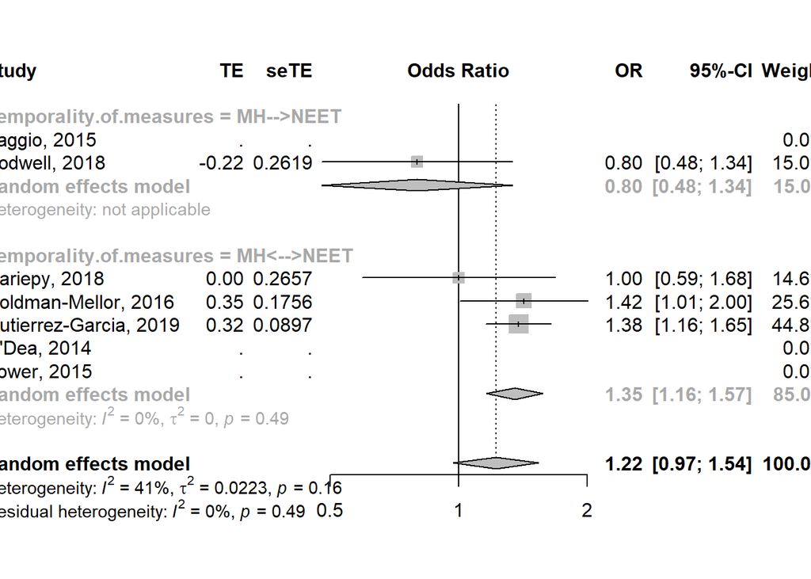

```r
forest(meta.MHalc.Gall.rep0.dir)
```

### ALCOHOL - geography

```r
meta.MHalc.Gall.rep0.geo<-update.meta(meta.MHalc.Gall.rep0,
                                      byvar=Country,
                                      comb.random = TRUE,
                                      comb.fixed = FALSE)
meta.MHalc.Gall.rep0.geo
```

```
##                            OR           95%-CI %W(random) Country
## Baggio, 2015               NA                         0.0       7
## Gariepy, 2018          1.0000 [0.5941; 1.6832]       14.6       2
## Goldman-Mellor, 2016   1.4200 [1.0066; 2.0032]       25.6       8
## Gutierrez-Garcia, 2019 1.3800 [1.1574; 1.6454]       44.8       5
## O'Dea, 2014                NA                         0.0       1
## Power, 2015                NA                         0.0       4
## Rodwell, 2018          0.8000 [0.4788; 1.3366]       15.0       1
##
## Number of studies combined: k = 4
##
##                          OR           95%-CI    z p-value
## Random effects model 1.2222 [0.9723; 1.5361] 1.72  0.0855
##
## Quantifying heterogeneity:
## tau^2 = 0.0223; H = 1.30 [1.00; 2.25]; I^2 = 41.2% [0.0%; 80.2%]
##
## Test of heterogeneity:
##     Q d.f. p-value
##  5.11    3  0.1642
##
## Results for subgroups (random effects model):
##                         k     OR           95%-CI    Q tau^2 I^2
## Country = Australia     1 0.8000 [0.4788; 1.3366] 0.00    --  --
## Country = Canada        1 1.0000 [0.5941; 1.6832] 0.00    --  --
## Country = Ireland       0     NA                    --    --  --
## Country = Mexico        1 1.3800 [1.1574; 1.6454] 0.00    --  --
## Country = Switzerland   0     NA                    --    --  --
## Country = UK            1 1.4200 [1.0066; 2.0032] 0.00    --  --
##
## Test for subgroup differences (random effects model):
##                     Q d.f. p-value
## Between groups   5.11    3  0.1642
##
## Details on meta-analytical method:
## - Inverse variance method
## - DerSimonian-Laird estimator for tau^2
```

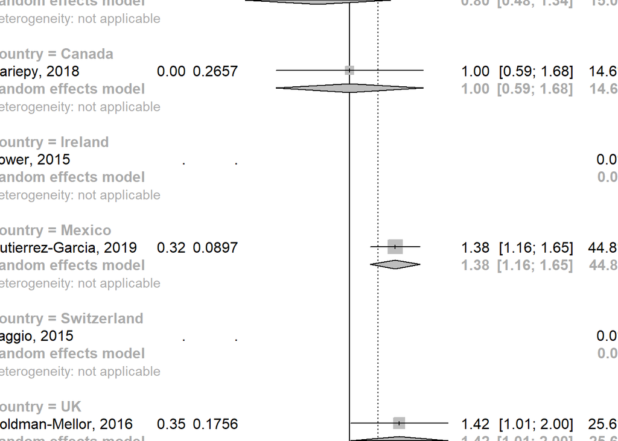

```r
forest(meta.MHalc.Gall.rep0.geo)
```

### ALCOHOL - gender

```r
MHalc.Gbg.rep0 <- neet2[which(neet2$Alcohol==1 & neet2$Gender!="all" & is.na(neet2$Repeated_sample)),]

head(MHalc.Gbg.rep0)
```

| X | Study | Country | study_no | Mental.health.measures | Temporality.of.measures | Results | Repeated_sample | MH_measure | MH.measure.included | Gender | OR | LowerCI | UpperCI | OR_ln | lower_ln | upper_ln | SE | LowerCI_sens | UpperCI_sens | Distress | Mood | Anxiety | Behavioral | Alcohol | Cannabis | Drug | Suicidal | Any |
| --- | --- | --- | --- | --- | --- | --- | --- | --- | --- | --- | --- | --- | --- | --- | --- | --- | --- | --- | --- | --- | --- | --- | --- | --- | --- | --- | --- | --- |

## CANNABIS

cannabis = 1, gender = all, repeated sample = 0

```r
MHcan.Gall.rep0 <- neet2[which(neet2$Cannabis==1 & neet2$Gender=="all" & is.na(neet2$Repeated_sample)),]

head(MHcan.Gall.rep0)
```

|  | X | Study | Country | study_no | Mental.health.measures | Temporality.of.measures | Results | Repeated_sample | MH_measure | MH.measure.included | Gender | OR | LowerCI | UpperCI | OR_ln | lower_ln | upper_ln | SE | LowerCI_sens | UpperCI_sens | Distress | Mood | Anxiety | Behavioral | Alcohol | Cannabis | Drug | Suicidal | Any |
| --- | --- | --- | --- | --- | --- | --- | --- | --- | --- | --- | --- | --- | --- | --- | --- | --- | --- | --- | --- | --- | --- | --- | --- | --- | --- | --- | --- | --- | --- |
| 25 | 5 | Baggio, 2015 | Switzerland | baggio 2015 4 | Cannabis use disorder | MH-->NEET | OR 1.09, P<0.001 | NA | cannabis | NA | all | 1.09 | 1.04 | 1.15 | 0.0861777 | 0.03922071 | 0.1397619 | 0.02564827 | NA | NA | 0 | 0 | 0 | 0 | 0 | 1 | 0 | 0 | 0 |
| 26 | 40 | Gariepy, 2018 | Canada | gariepy 2018 5 | Cannabis disorder | MHNEET | OR 1.0, 95% CI 0.5, 2.0 | NA | cannabis | NA | all | 1.00 | 0.50 | 2.00 | 0.0000000 | -0.69314718 | 0.6931472 | 0.35364652 | NA | NA | 0 | 0 | 0 | 0 | 0 | 1 | 0 | 0 | 0 |
| 27 | 47 | Goldman-Mellor, 2016 | UK | goldman 2016 4 | Cannabis dependence | MHNEET | OR 3.93, 95% CI 2.31, 6.68 | NA | cannabis | NA | all | 3.93 | 2.31 | 6.68 | 1.3686394 | 0.83724752 | 1.8991180 | 0.27088532 | NA | NA | 0 | 0 | 0 | 0 | 0 | 1 | 0 | 0 | 0 |
| 28 | 103 | O'Dea, 2014 | Australia | odea 2014 4 | Cannabis use disorder | MHNEET | OR 1.22, 95% CI 0.72, 2.05 | NA | cannabis | NA | all | 1.22 | 0.72 | 2.05 | 0.1988509 | -0.32850407 | 0.7178398 | 0.26692445 | NA | NA | 0 | 0 | 0 | 0 | 0 | 1 | 0 | 0 | 0 |
| 29 | 119 | Rodwell, 2018 | Australia | rodwell 2018 3 | Cannabis use disorder | MH-->NEET | OR 1.74, 95% CI 1.10, 2.75 | NA | cannabis | NA | all | 1.74 | 1.10 | 2.75 | 0.5538851 | 0.09531018 | 1.0116009 | 0.23374764 | NA | NA | 0 | 0 | 0 | 0 | 0 | 1 | 0 | 0 | 0 |

```r
meta.MHcan.Gall.rep0 <- metagen(OR_ln,
                                SE,
                                data=MHcan.Gall.rep0,
                                studlab=paste(Study),
                                comb.fixed = FALSE,
                                comb.random = TRUE,
                                method.tau = "DL",
                                hakn = FALSE,
                                prediction=FALSE,
                                sm="OR")
meta.MHcan.Gall.rep0
```

```
##                          OR           95%-CI %W(random)
## Baggio, 2015         1.0900 [1.0366; 1.1462]       25.5
## Gariepy, 2018        1.0000 [0.5000; 2.0000]       16.1
## Goldman-Mellor, 2016 3.9300 [2.3111; 6.6830]       19.0
## O'Dea, 2014          1.2200 [0.7230; 2.0586]       19.1
## Rodwell, 2018        1.7400 [1.1005; 2.7512]       20.3
##
## Number of studies combined: k = 5
##
##                          OR           95%-CI    z p-value
## Random effects model 1.5408 [0.9779; 2.4279] 1.86  0.0624
##
## Quantifying heterogeneity:
## tau^2 = 0.2102; H = 2.56 [1.71; 3.82]; I^2 = 84.7% [65.9%; 93.2%]
##
## Test of heterogeneity:
##      Q d.f.  p-value
##  26.19    4 < 0.0001
##
## Details on meta-analytical method:
## - Inverse variance method
## - DerSimonian-Laird estimator for tau^2
```

### CANNABIS - directionality

```r
meta.MHcan.Gall.rep0.dir<-update.meta(meta.MHcan.Gall.rep0,
                                      byvar=Temporality.of.measures,
                                      comb.random = TRUE,
                                      comb.fixed = FALSE)
meta.MHcan.Gall.rep0.dir
```

```
##                          OR           95%-CI %W(random) Temporality.of.measures
## Baggio, 2015         1.0900 [1.0366; 1.1462]       25.5                       1
## Gariepy, 2018        1.0000 [0.5000; 2.0000]       16.1                       2
## Goldman-Mellor, 2016 3.9300 [2.3111; 6.6830]       19.0                       2
## O'Dea, 2014          1.2200 [0.7230; 2.0586]       19.1                       2
## Rodwell, 2018        1.7400 [1.1005; 2.7512]       20.3                       1
##
## Number of studies combined: k = 5
##
##                          OR           95%-CI    z p-value
## Random effects model 1.5408 [0.9779; 2.4279] 1.86  0.0624
##
## Quantifying heterogeneity:
## tau^2 = 0.2102; H = 2.56 [1.71; 3.82]; I^2 = 84.7% [65.9%; 93.2%]
##
## Quantifying residual heterogeneity:
## H = 2.39 [1.49; 3.83]; I^2 = 82.5% [55.0%; 93.2%]
##
## Test of heterogeneity:
##      Q d.f.  p-value
##  26.19    4 < 0.0001
##
## Results for subgroups (random effects model):
##                                        k     OR           95%-CI     Q  tau^2
## Temporality.of.measures = MH-->NEET    2 1.2999 [0.8337; 2.0269]  3.96 0.0817
## Temporality.of.measures = MH<-->NEET   3 1.7113 [0.7269; 4.0288] 13.19 0.4836
##                                        I^2
## Temporality.of.measures = MH-->NEET  74.7%
## Temporality.of.measures = MH<-->NEET 84.8%
##
## Test for subgroup differences (random effects model):
##                     Q d.f. p-value
## Between groups   0.31    1  0.5764
##
## Details on meta-analytical method:
## - Inverse variance method
## - DerSimonian-Laird estimator for tau^2
```

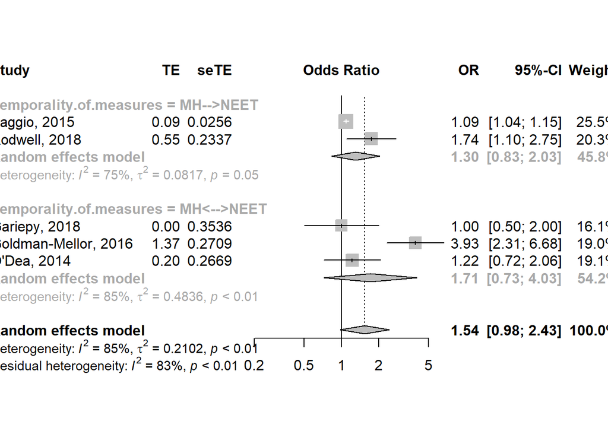

```r
forest(meta.MHcan.Gall.rep0.dir)
```

### CANNABIS - geography

```r
meta.MHcan.Gall.rep0.geo<-update.meta(meta.MHcan.Gall.rep0,
                                      byvar=Country,
                                      comb.random = TRUE,
                                      comb.fixed = FALSE)
meta.MHcan.Gall.rep0.geo
```

```
##                          OR           95%-CI %W(random) Country
## Baggio, 2015         1.0900 [1.0366; 1.1462]       25.5       7
## Gariepy, 2018        1.0000 [0.5000; 2.0000]       16.1       2
## Goldman-Mellor, 2016 3.9300 [2.3111; 6.6830]       19.0       8
## O'Dea, 2014          1.2200 [0.7230; 2.0586]       19.1       1
## Rodwell, 2018        1.7400 [1.1005; 2.7512]       20.3       1
##
## Number of studies combined: k = 5
##
##                          OR           95%-CI    z p-value
## Random effects model 1.5408 [0.9779; 2.4279] 1.86  0.0624
##
## Quantifying heterogeneity:
## tau^2 = 0.2102; H = 2.56 [1.71; 3.82]; I^2 = 84.7% [65.9%; 93.2%]
##
## Quantifying residual heterogeneity:
## H = 1.00; I^2 = 0.1%
##
## Test of heterogeneity:
##      Q d.f.  p-value
##  26.19    4 < 0.0001
##
## Results for subgroups (random effects model):
##                         k     OR           95%-CI    Q   tau^2  I^2
## Country = Australia     2 1.4915 [1.0564; 2.1057] 1.00 <0.0001 0.1%
## Country = Canada        1 1.0000 [0.5000; 2.0000] 0.00      --   --
## Country = Switzerland   1 1.0900 [1.0366; 1.1462] 0.00      --   --
## Country = UK            1 3.9300 [2.3111; 6.6830] 0.00      --   --
##
## Test for subgroup differences (random effects model):
##                      Q d.f.  p-value
## Between groups   25.19    3 < 0.0001
##
## Details on meta-analytical method:
## - Inverse variance method
## - DerSimonian-Laird estimator for tau^2
```

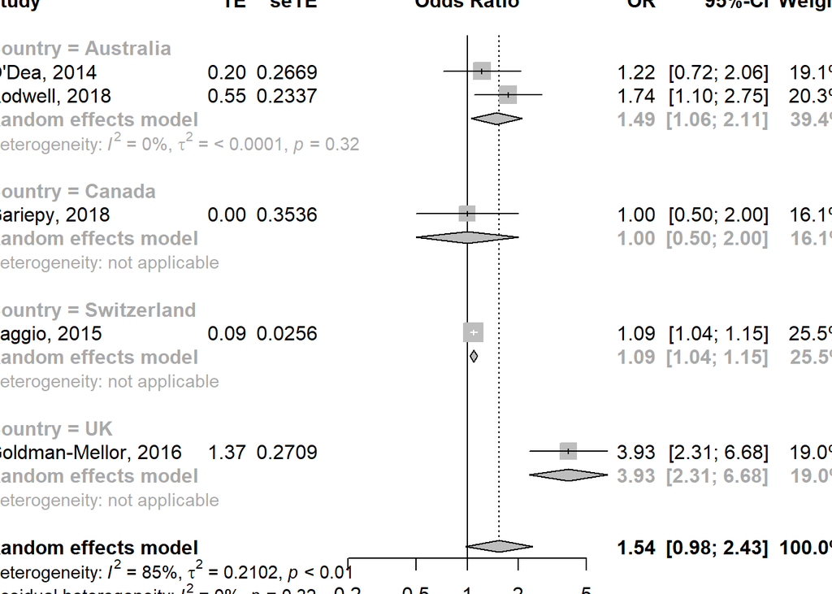

```r
forest(meta.MHcan.Gall.rep0.geo)
```

### CANNABIS - gender

```r
MHcan.Gbg.rep0 <- neet2[which(neet2$Cannabis==1 & neet2$Gender!="all" & is.na(neet2$Repeated_sample)),]

head(MHcan.Gbg.rep0)
```

| X | Study | Country | study_no | Mental.health.measures | Temporality.of.measures | Results | Repeated_sample | MH_measure | MH.measure.included | Gender | OR | LowerCI | UpperCI | OR_ln | lower_ln | upper_ln | SE | LowerCI_sens | UpperCI_sens | Distress | Mood | Anxiety | Behavioral | Alcohol | Cannabis | Drug | Suicidal | Any |
| --- | --- | --- | --- | --- | --- | --- | --- | --- | --- | --- | --- | --- | --- | --- | --- | --- | --- | --- | --- | --- | --- | --- | --- | --- | --- | --- | --- | --- |

## DRUG

drug = 1, gender = all, repeated sample = 0

```r
MHdrg.Gall.rep0 <- neet2[which(neet2$Drug==1 & neet2$Gender=="all" & is.na(neet2$Repeated_sample)),]

head(MHdrg.Gall.rep0)
```

|  | X | Study | Country | study_no | Mental.health.measures | Temporality.of.measures | Results | Repeated_sample | MH_measure | MH.measure.included | Gender | OR | LowerCI | UpperCI | OR_ln | lower_ln | upper_ln | SE | LowerCI_sens | UpperCI_sens | Distress | Mood | Anxiety | Behavioral | Alcohol | Cannabis | Drug | Suicidal | Any |
| --- | --- | --- | --- | --- | --- | --- | --- | --- | --- | --- | --- | --- | --- | --- | --- | --- | --- | --- | --- | --- | --- | --- | --- | --- | --- | --- | --- | --- | --- |
| 11 | 20 | Basta, 2019 | Greece | basta 2019 7 | Drug use | MHNEET | All: OR 0.80, 95% CI 0.58, 1.1 | NA | drug | NA | all | 0.80 | 0.58 | 1.10 | -0.2231436 | -0.5447272 | 0.09531018 | 0.16327484 | NA | NA | 0 | 0 | 0 | 0 | 0 | 0 | 1 | 0 | 0 |
| 14 | 26 | Benjet, 2012 | Mexico | benjet 2012 3 | Substance use disorder | MHNEET | OR 4.4, 95% CI 2.6, 7.6 | NA | drug | NA | all | 4.40 | 2.60 | 7.60 | 1.4816045 | 0.9555114 | 2.02814825 | 0.27363184 | NA | NA | 0 | 0 | 0 | 0 | 0 | 0 | 1 | 0 | 0 |
| 15 | 41 | Gariepy, 2018 | Canada | gariepy 2018 6 | Drug use disorder | MHNEET | OR 3.2, 95% CI 1.3, 7.8 | NA | drug | NA | all | 3.20 | 1.30 | 7.80 | 1.1631508 | 0.2623643 | 2.05412373 | 0.45708150 | NA | NA | 0 | 0 | 0 | 0 | 0 | 0 | 1 | 0 | 0 |
| 16 | 52 | Goldman-Mellor, 2016 | UK | goldman 2016 8 | Harmful substance use | MH-->NEET | OR 1.89, 95% CI 1.29, 2.77 | NA | drug | NA | all | 1.89 | 1.29 | 2.77 | 0.6365768 | 0.2546422 | 1.01884732 | 0.19495028 | NA | NA | 0 | 0 | 0 | 0 | 0 | 0 | 1 | 0 | 0 |
| 19 | 88 | Henderson, 2017 | Canada | henderson 2017 11 | Substance use disorder | MHNEET | Total: OR 1.94, 95% CI 1.63, 2.31 | NA | drug | NA | all | 1.94 | 1.63 | 2.31 | 0.6626880 | 0.4885800 | 0.83724752 | 0.08894579 | NA | NA | 0 | 0 | 0 | 0 | 0 | 0 | 1 | 0 | 0 |
| 24 | 108 | Power, 2015 | Ireland | power 2015 4 | Drug use disorder (lifetime) | MHNEET | OR NA, P>0.05 | NA | drug | NA | all | NA | NA | NA | NA | NA | NA | NA | NA | NA | 0 | 0 | 0 | 0 | 0 | 0 | 1 | 0 | 0 |

```r
meta.MHdrg.Gall.rep0 <- metagen(OR_ln,
                                SE,
                                data=MHdrg.Gall.rep0,
                                studlab=paste(Study),
                                comb.fixed = FALSE,
                                comb.random = TRUE,
                                method.tau = "DL",
                                hakn = FALSE,
                                prediction=FALSE,
                                sm="OR")
meta.MHdrg.Gall.rep0
```

```
##                          OR           95%-CI %W(random)
## Basta, 2019          0.8000 [0.5809; 1.1017]       22.1
## Benjet, 2012         4.4000 [2.5736; 7.5226]       19.1
## Gariepy, 2018        3.2000 [1.3064; 7.8382]       13.9
## Goldman-Mellor, 2016 1.8900 [1.2898; 2.7695]       21.3
## Henderson, 2017      1.9400 [1.6296; 2.3095]       23.6
## Power, 2015              NA                         0.0
##
## Number of studies combined: k = 5
##
##                          OR           95%-CI    z p-value
## Random effects model 1.9875 [1.1945; 3.3070] 2.64  0.0082
##
## Quantifying heterogeneity:
## tau^2 = 0.2783; H = 3.06 [2.13; 4.41]; I^2 = 89.4% [77.9%; 94.9%]
##
## Test of heterogeneity:
##      Q d.f.  p-value
##  37.58    4 < 0.0001
##
## Details on meta-analytical method:
## - Inverse variance method
## - DerSimonian-Laird estimator for tau^2
```

### DRUG - directionality

```r
meta.MHdrg.Gall.rep0.dir<-update.meta(meta.MHdrg.Gall.rep0,
                                      byvar=Temporality.of.measures,
                                      comb.random = TRUE,
                                      comb.fixed = FALSE)
meta.MHdrg.Gall.rep0.dir
```

```
##                          OR           95%-CI %W(random) Temporality.of.measures
## Basta, 2019          0.8000 [0.5809; 1.1017]       22.1                       2
## Benjet, 2012         4.4000 [2.5736; 7.5226]       19.1                       2
## Gariepy, 2018        3.2000 [1.3064; 7.8382]       13.9                       2
## Goldman-Mellor, 2016 1.8900 [1.2898; 2.7695]       21.3                       1
## Henderson, 2017      1.9400 [1.6296; 2.3095]       23.6                       2
## Power, 2015              NA                         0.0                       2
##
## Number of studies combined: k = 5
##
##                          OR           95%-CI    z p-value
## Random effects model 1.9875 [1.1945; 3.3070] 2.64  0.0082
##
## Quantifying heterogeneity:
## tau^2 = 0.2783; H = 3.06 [2.13; 4.41]; I^2 = 89.4% [77.9%; 94.9%]
##
## Quantifying residual heterogeneity:
## H = 3.53 [2.40; 5.19]; I^2 = 92.0% [82.7%; 96.3%]
##
## Test of heterogeneity:
##      Q d.f.  p-value
##  37.58    4 < 0.0001
##
## Results for subgroups (random effects model):
##                                        k     OR           95%-CI     Q  tau^2
## Temporality.of.measures = MH-->NEET    1 1.8900 [1.2898; 2.7695]  0.00     --
## Temporality.of.measures = MH<-->NEET   4 2.0503 [1.0465; 4.0171] 37.42 0.4027
##                                        I^2
## Temporality.of.measures = MH-->NEET     --
## Temporality.of.measures = MH<-->NEET 92.0%
##
## Test for subgroup differences (random effects model):
##                     Q d.f. p-value
## Between groups   0.04    1  0.8365
##
## Details on meta-analytical method:
## - Inverse variance method
## - DerSimonian-Laird estimator for tau^2
```

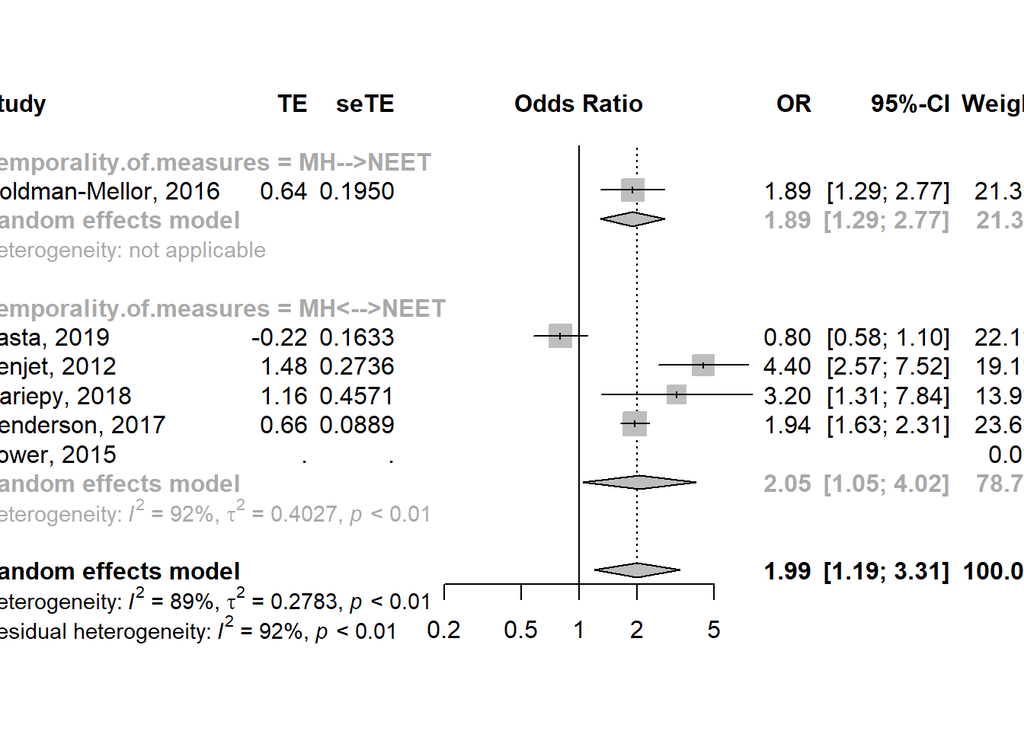

```r
forest(meta.MHdrg.Gall.rep0.dir)
```

### DRUG - geography

```r
meta.MHdrg.Gall.rep0.geo<-update.meta(meta.MHdrg.Gall.rep0,
                                      byvar=Country,
                                      comb.random = TRUE,
                                      comb.fixed = FALSE)
meta.MHdrg.Gall.rep0.geo
```

```
##                          OR           95%-CI %W(random) Country
## Basta, 2019          0.8000 [0.5809; 1.1017]       22.1       3
## Benjet, 2012         4.4000 [2.5736; 7.5226]       19.1       5
## Gariepy, 2018        3.2000 [1.3064; 7.8382]       13.9       2
## Goldman-Mellor, 2016 1.8900 [1.2898; 2.7695]       21.3       8
## Henderson, 2017      1.9400 [1.6296; 2.3095]       23.6       2
## Power, 2015              NA                         0.0       4
##
## Number of studies combined: k = 5
##
##                          OR           95%-CI    z p-value
## Random effects model 1.9875 [1.1945; 3.3070] 2.64  0.0082
##
## Quantifying heterogeneity:
## tau^2 = 0.2783; H = 3.06 [2.13; 4.41]; I^2 = 89.4% [77.9%; 94.9%]
##
## Quantifying residual heterogeneity:
## H = 1.07; I^2 = 13.4%
##
## Test of heterogeneity:
##      Q d.f.  p-value
##  37.58    4 < 0.0001
##
## Results for subgroups (random effects model):
##                     k     OR           95%-CI    Q  tau^2   I^2
## Country = Canada    2 2.0383 [1.5212; 2.7310] 1.16 0.0168 13.4%
## Country = Greece    1 0.8000 [0.5809; 1.1017] 0.00     --    --
## Country = Ireland   0     NA                    --     --    --
## Country = Mexico    1 4.4000 [2.5736; 7.5226] 0.00     --    --
## Country = UK        1 1.8900 [1.2898; 2.7695] 0.00     --    --
##
## Test for subgroup differences (random effects model):
##                      Q d.f.  p-value
## Between groups   34.99    3 < 0.0001
##
## Details on meta-analytical method:
## - Inverse variance method
## - DerSimonian-Laird estimator for tau^2
```

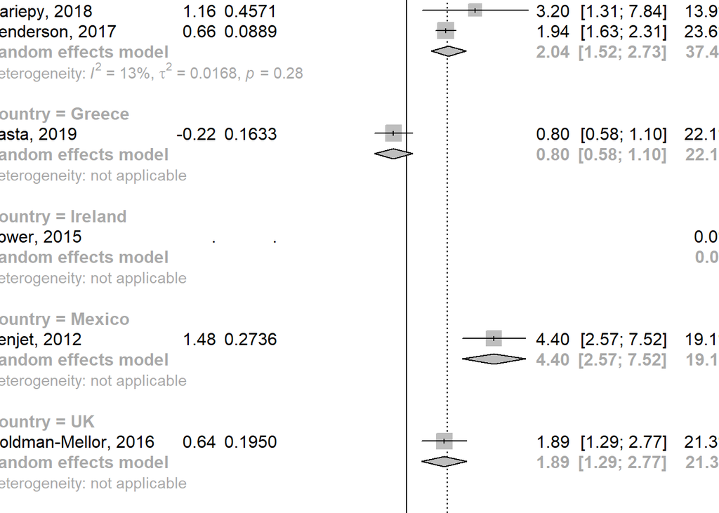

```r
forest(meta.MHdrg.Gall.rep0.geo)
```

### DRUG - gender

```r
MHdrg.Gbg.rep0 <- neet2[which(neet2$Drug==1 & neet2$Gender!="all" & is.na(neet2$Repeated_sample)),]

head(MHdrg.Gbg.rep0)
```

|  | X | Study | Country | study_no | Mental.health.measures | Temporality.of.measures | Results | Repeated_sample | MH_measure | MH.measure.included | Gender | OR | LowerCI | UpperCI | OR_ln | lower_ln | upper_ln | SE | LowerCI_sens | UpperCI_sens | Distress | Mood | Anxiety | Behavioral | Alcohol | Cannabis | Drug | Suicidal | Any |
| --- | --- | --- | --- | --- | --- | --- | --- | --- | --- | --- | --- | --- | --- | --- | --- | --- | --- | --- | --- | --- | --- | --- | --- | --- | --- | --- | --- | --- | --- |
| 12 | 21 | Basta, 2019 | Greece | basta 2019 8 | Drug use | MHNEET | Males: OR 0.99, 95% CI 0.67, 1.48 | NA | drug | NA | boy | 0.99 | 0.67 | 1.48 | -0.01005034 | -0.4004776 | 0.3920421 | 0.2021734 | NA | NA | 0 | 0 | 0 | 0 | 0 | 0 | 1 | 0 | 0 |
| 13 | 22 | Basta, 2019 | Greece | basta 2019 9 | Drug use | MHNEET | Females: OR 0.52, 95% CI 0.28, 0.94 | NA | drug | NA | girl | 0.52 | 0.28 | 0.94 | -0.65392647 | -1.2729657 | -0.0618754 | 0.3089516 | NA | NA | 0 | 0 | 0 | 0 | 0 | 0 | 1 | 0 | 0 |
| 20 | 89 | Henderson, 2017 | Canada | henderson 2017 12 | Substance use disorder | MHNEET | Age<18: OR 1.44, 95% CI 1.21, 1.88 | NA | drug | NA | age | 1.44 | 1.21 | 1.88 | 0.36464311 | 0.1906204 | 0.6312718 | 0.1124111 | NA | NA | 0 | 0 | 0 | 0 | 0 | 0 | 1 | 0 | 0 |
| 21 | 90 | Henderson, 2017 | Canada | henderson 2017 13 | Substance use disorder | MHNEET | Age=18: OR 2.19, 95% CI 1.68, 2.84 | NA | drug | NA | age | 2.19 | 1.68 | 2.84 | 0.78390154 | 0.5187938 | 1.0438041 | 0.1339312 | NA | NA | 0 | 0 | 0 | 0 | 0 | 0 | 1 | 0 | 0 |
| 22 | 91 | Henderson, 2017 | Canada | henderson 2017 14 | Substance use disorder | MHNEET | Boys: OR 1.83, 95% CI 1.43, 2.34 | NA | drug | NA | boy | 1.83 | 1.43 | 2.34 | 0.60431597 | 0.3576744 | 0.8501509 | 0.1256318 | NA | NA | 0 | 0 | 0 | 0 | 0 | 0 | 1 | 0 | 0 |
| 23 | 92 | Henderson, 2017 | Canada | henderson 2017 15 | Substance use disorder | MHNEET | Girls: OR 2.05, 95% CI 1.58, 2.66 | NA | drug | NA | girl | 2.05 | 1.58 | 2.66 | 0.71783979 | 0.4574248 | 0.9783261 | 0.1328830 | NA | NA | 0 | 0 | 0 | 0 | 0 | 0 | 1 | 0 | 0 |

```r
meta.MHdrg.Gbg.rep0 <- metagen(OR_ln,
                               SE,
                               data=MHdrg.Gbg.rep0,
                               studlab=paste(Study),
                               comb.fixed = FALSE,
                               comb.random = TRUE,
                               method.tau = "DL",
                               hakn = FALSE,
                               prediction=FALSE,
                               sm="OR")
meta.MHdrg.Gbg.rep0
```

```
##                     OR           95%-CI %W(random)
## Basta, 2019     0.9900 [0.6661; 1.4714]       15.3
## Basta, 2019     0.5200 [0.2838; 0.9528]       11.2
## Henderson, 2017 1.4400 [1.1553; 1.7949]       18.9
## Henderson, 2017 2.1900 [1.6844; 2.8474]       18.1
## Henderson, 2017 1.8300 [1.4306; 2.3409]       18.4
## Henderson, 2017 2.0500 [1.5800; 2.6599]       18.1
##
## Number of studies combined: k = 6
##
##                          OR           95%-CI    z p-value
## Random effects model 1.4588 [1.0864; 1.9589] 2.51  0.0120
##
## Quantifying heterogeneity:
## tau^2 = 0.1070; H = 2.43 [1.68; 3.53]; I^2 = 83.1% [64.6%; 92.0%]
##
## Test of heterogeneity:
##      Q d.f.  p-value
##  29.63    5 < 0.0001
##
## Details on meta-analytical method:
## - Inverse variance method
## - DerSimonian-Laird estimator for tau^2
```

```r
meta.MHdrg.Gbg.rep0<-update.meta(meta.MHdrg.Gbg.rep0,
                                 byvar=Gender,
                                 comb.random = TRUE,
                                 comb.fixed = FALSE)
meta.MHdrg.Gbg.rep0
```

```
##                     OR           95%-CI %W(random) Gender
## Basta, 2019     0.9900 [0.6661; 1.4714]       15.3      3
## Basta, 2019     0.5200 [0.2838; 0.9528]       11.2      4
## Henderson, 2017 1.4400 [1.1553; 1.7949]       18.9      1
## Henderson, 2017 2.1900 [1.6844; 2.8474]       18.1      1
## Henderson, 2017 1.8300 [1.4306; 2.3409]       18.4      3
## Henderson, 2017 2.0500 [1.5800; 2.6599]       18.1      4
##
## Number of studies combined: k = 6
##
##                          OR           95%-CI    z p-value
## Random effects model 1.4588 [1.0864; 1.9589] 2.51  0.0120
##
## Quantifying heterogeneity:
## tau^2 = 0.1070; H = 2.43 [1.68; 3.53]; I^2 = 83.1% [64.6%; 92.0%]
##
## Quantifying residual heterogeneity:
## H = 3.11 [2.06; 4.70]; I^2 = 89.7% [76.4%; 95.5%]
##
## Test of heterogeneity:
##      Q d.f.  p-value
##  29.63    5 < 0.0001
##
## Results for subgroups (random effects model):
##                 k     OR           95%-CI     Q  tau^2   I^2
## Gender = age    2 1.7646 [1.1703; 2.6608]  5.75 0.0726 82.6%
## Gender = boy    2 1.3738 [0.7534; 2.5050]  6.66 0.1604 85.0%
## Gender = girl   2 1.0622 [0.2772; 4.0693] 16.64 0.8843 94.0%
##
## Test for subgroup differences (random effects model):
##                     Q d.f. p-value
## Between groups   0.82    2  0.6632
##
## Details on meta-analytical method:
## - Inverse variance method
## - DerSimonian-Laird estimator for tau^2
```

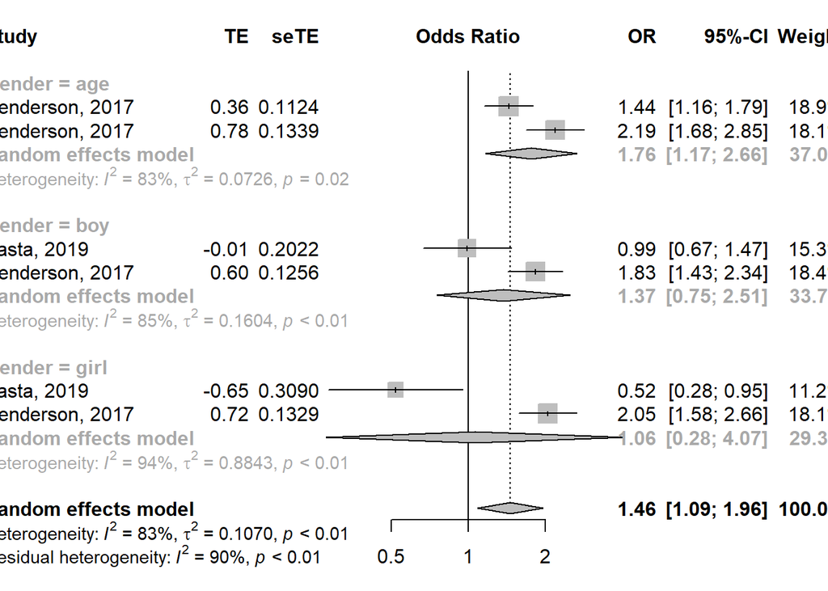

```r
forest(meta.MHdrg.Gbg.rep0)
```

## SUICIDAL

suicidal = 1, gender = all, repeated sample = 0

```r
MHsui.Gall.rep0 <- neet2[which(neet2$Suicidal==1 & neet2$Gender=="all" & is.na(neet2$Repeated_sample)),]

head(MHsui.Gall.rep0)
```

|  | X | Study | Country | study_no | Mental.health.measures | Temporality.of.measures | Results | Repeated_sample | MH_measure | MH.measure.included | Gender | OR | LowerCI | UpperCI | OR_ln | lower_ln | upper_ln | SE | LowerCI_sens | UpperCI_sens | Distress | Mood | Anxiety | Behavioral | Alcohol | Cannabis | Drug | Suicidal | Any |
| --- | --- | --- | --- | --- | --- | --- | --- | --- | --- | --- | --- | --- | --- | --- | --- | --- | --- | --- | --- | --- | --- | --- | --- | --- | --- | --- | --- | --- | --- |
| 5 | 31 | Benjet, 2012 | Mexico | benjet 2012 8 | Suicidal attempt | MHNEET | OR 3.6, 95% CI 2.0, 6.4 | NA | suicide | NA | all | 3.6 | 2.00 | 6.40 | 1.2809338 | 0.6931472 | 1.856298 | 0.2967221 | NA | NA | 0 | 0 | 0 | 0 | 0 | 0 | 0 | 1 | 0 |
| 6 | 42 | Gariepy, 2018 | Canada | gariepy 2018 7 | Suicidal ideation | MHNEET | OR 1.8, 95% CI 1.0, 3.1 | NA | suicide | NA | all | 1.8 | 1.00 | 3.10 | 0.5877867 | 0.0000000 | 1.131402 | 0.2886230 | NA | NA | 0 | 0 | 0 | 0 | 0 | 0 | 0 | 1 | 0 |
| 7 | 53 | Goldman-Mellor, 2016 | UK | goldman 2016 9 | Suicidal behaviours | MH-->NEET | OR 3.30, 95% CI 2.07, 5.27 | NA | suicide | NA | all | 3.3 | 2.07 | 5.27 | 1.1939225 | 0.7275486 | 1.662030 | 0.2383882 | NA | NA | 0 | 0 | 0 | 0 | 0 | 0 | 0 | 1 | 0 |
| 10 | 110 | Power, 2015 | Ireland | power 2015 6 | Suicidal attempts (lifetime) | MHNEET | OR 3.1, 95% CI 1.0, 9.3 | NA | suicide | NA | all | 3.1 | 1.00 | 9.30 | 1.1314021 | 0.0000000 | 2.230014 | 0.5688812 | NA | NA | 0 | 0 | 0 | 0 | 0 | 0 | 0 | 1 | 0 |

```r
meta.MHsui.Gall.rep0 <- metagen(OR_ln,
                                SE,
                                data=MHsui.Gall.rep0,
                                studlab=paste(Study),
                                comb.fixed = FALSE,
                                comb.random = TRUE,
                                method.tau = "DL",
                                hakn = FALSE,
                                prediction=FALSE,
                                sm="OR")
meta.MHsui.Gall.rep0
```

```
##                          OR           95%-CI %W(random)
## Benjet, 2012         3.6000 [2.0125; 6.4398]       26.5
## Gariepy, 2018        1.8000 [1.0223; 3.1692]       27.7
## Goldman-Mellor, 2016 3.3000 [2.0682; 5.2654]       37.5
## Power, 2015          3.1000 [1.0166; 9.4535]        8.2
##
## Number of studies combined: k = 4
##
##                          OR           95%-CI    z  p-value
## Random effects model 2.8397 [2.0441; 3.9450] 6.22 < 0.0001
##
## Quantifying heterogeneity:
## tau^2 = 0.0181; H = 1.09 [1.00; 2.78]; I^2 = 15.6% [0.0%; 87.1%]
##
## Test of heterogeneity:
##     Q d.f. p-value
##  3.55    3  0.3137
##
## Details on meta-analytical method:
## - Inverse variance method
## - DerSimonian-Laird estimator for tau^2
```

### SUICIDAL - directionality

```r
meta.MHsui.Gall.rep0.dir<-update.meta(meta.MHsui.Gall.rep0,
                                      byvar=Temporality.of.measures,
                                      comb.random = TRUE,
                                      comb.fixed = FALSE)
meta.MHsui.Gall.rep0.dir
```

```
##                          OR           95%-CI %W(random) Temporality.of.measures
## Benjet, 2012         3.6000 [2.0125; 6.4398]       26.5                       2
## Gariepy, 2018        1.8000 [1.0223; 3.1692]       27.7                       2
## Goldman-Mellor, 2016 3.3000 [2.0682; 5.2654]       37.5                       1
## Power, 2015          3.1000 [1.0166; 9.4535]        8.2                       2
##
## Number of studies combined: k = 4
##
##                          OR           95%-CI    z  p-value
## Random effects model 2.8397 [2.0441; 3.9450] 6.22 < 0.0001
##
## Quantifying heterogeneity:
## tau^2 = 0.0181; H = 1.09 [1.00; 2.78]; I^2 = 15.6% [0.0%; 87.1%]
##
## Quantifying residual heterogeneity:
## H = 1.21 [1.00; 3.75]; I^2 = 31.5% [0.0%; 92.9%]
##
## Test of heterogeneity:
##     Q d.f. p-value
##  3.55    3  0.3137
##
## Results for subgroups (random effects model):
##                                        k     OR           95%-CI    Q  tau^2
## Temporality.of.measures = MH-->NEET    1 3.3000 [2.0682; 5.2654] 0.00     --
## Temporality.of.measures = MH<-->NEET   3 2.6138 [1.6135; 4.2344] 2.92 0.0584
##                                        I^2
## Temporality.of.measures = MH-->NEET     --
## Temporality.of.measures = MH<-->NEET 31.5%
##
## Test for subgroup differences (random effects model):
##                     Q d.f. p-value
## Between groups   0.46    1  0.4963
##
## Details on meta-analytical method:
## - Inverse variance method
## - DerSimonian-Laird estimator for tau^2
```

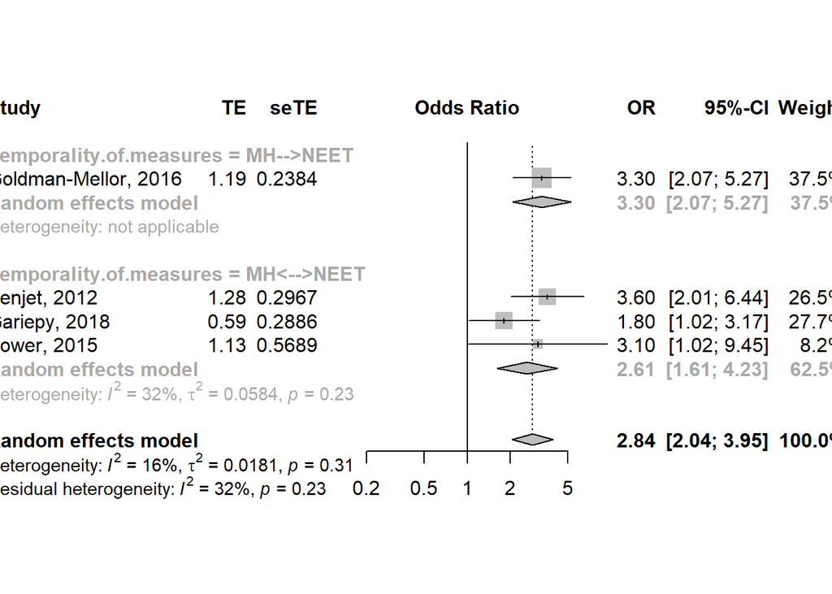

```r
forest(meta.MHsui.Gall.rep0.dir)
```

### SUICIDAL - geography

```r
meta.MHsui.Gall.rep0.geo<-update.meta(meta.MHsui.Gall.rep0,
                                      byvar=Country,
                                      comb.random = TRUE,
                                      comb.fixed = FALSE)
meta.MHsui.Gall.rep0.geo
```

```
##                          OR           95%-CI %W(random) Country
## Benjet, 2012         3.6000 [2.0125; 6.4398]       26.5       5
## Gariepy, 2018        1.8000 [1.0223; 3.1692]       27.7       2
## Goldman-Mellor, 2016 3.3000 [2.0682; 5.2654]       37.5       8
## Power, 2015          3.1000 [1.0166; 9.4535]        8.2       4
##
## Number of studies combined: k = 4
##
##                          OR           95%-CI    z  p-value
## Random effects model 2.8397 [2.0441; 3.9450] 6.22 < 0.0001
##
## Quantifying heterogeneity:
## tau^2 = 0.0181; H = 1.09 [1.00; 2.78]; I^2 = 15.6% [0.0%; 87.1%]
##
## Test of heterogeneity:
##     Q d.f. p-value
##  3.55    3  0.3137
##
## Results for subgroups (random effects model):
##                     k     OR           95%-CI    Q tau^2 I^2
## Country = Canada    1 1.8000 [1.0223; 3.1692] 0.00    --  --
## Country = Ireland   1 3.1000 [1.0166; 9.4535] 0.00    --  --
## Country = Mexico    1 3.6000 [2.0125; 6.4398] 0.00    --  --
## Country = UK        1 3.3000 [2.0682; 5.2654] 0.00    --  --
##
## Test for subgroup differences (random effects model):
##                     Q d.f. p-value
## Between groups   3.55    3  0.3137
##
## Details on meta-analytical method:
## - Inverse variance method
## - DerSimonian-Laird estimator for tau^2
```

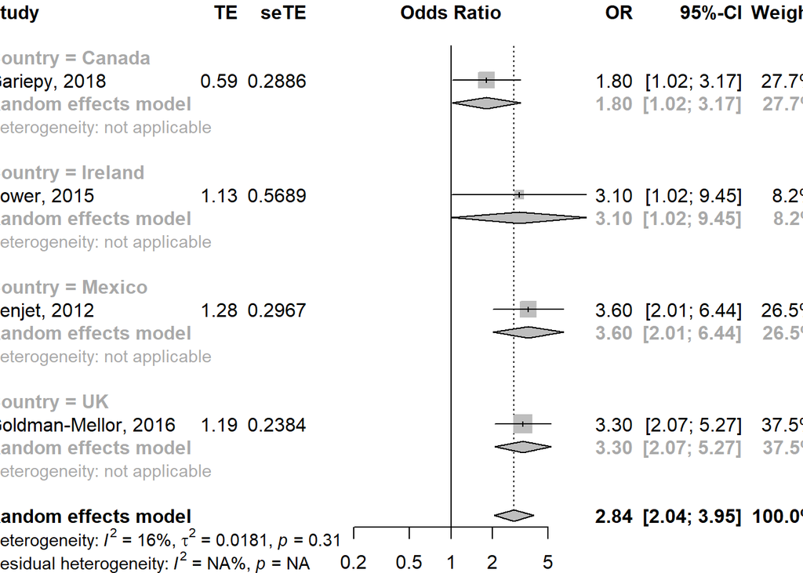

```r
forest(meta.MHsui.Gall.rep0.geo)
```

### SUICIDAL - gender

```r
MHsui.Gbg.rep0 <- neet2[which(neet2$Suicidal==1 & neet2$Gender!="all" & is.na(neet2$Repeated_sample)),]

head(MHsui.Gbg.rep0)
```

| X | Study | Country | study_no | Mental.health.measures | Temporality.of.measures | Results | Repeated_sample | MH_measure | MH.measure.included | Gender | OR | LowerCI | UpperCI | OR_ln | lower_ln | upper_ln | SE | LowerCI_sens | UpperCI_sens | Distress | Mood | Anxiety | Behavioral | Alcohol | Cannabis | Drug | Suicidal | Any |
| --- | --- | --- | --- | --- | --- | --- | --- | --- | --- | --- | --- | --- | --- | --- | --- | --- | --- | --- | --- | --- | --- | --- | --- | --- | --- | --- | --- | --- |

## ANY

any = 1, gender = all, repeated sample = 0

```r
MHany.Gall.rep0 <- neet2[which(neet2$Any==1 & neet2$Gender=="all" & is.na(neet2$Repeated_sample)),]

head(MHany.Gall.rep0)
```

|  | X | Study | Country | study_no | Mental.health.measures | Temporality.of.measures | Results | Repeated_sample | MH_measure | MH.measure.included | Gender | OR | LowerCI | UpperCI | OR_ln | lower_ln | upper_ln | SE | LowerCI_sens | UpperCI_sens | Distress | Mood | Anxiety | Behavioral | Alcohol | Cannabis | Drug | Suicidal | Any |
| --- | --- | --- | --- | --- | --- | --- | --- | --- | --- | --- | --- | --- | --- | --- | --- | --- | --- | --- | --- | --- | --- | --- | --- | --- | --- | --- | --- | --- | --- |
| 1 | 28 | Benjet, 2012 | Mexico | benjet 2012 5 | Any disorder | MHNEET | OR 1.7, 95% CI 1.3, 2.3 | NA | any | NA | all | 1.7 | 1.30 | 2.3 | 0.5306283 | 0.26236426 | 0.8329091 | 0.1455472 | NA | NA | 0 | 0 | 0 | 0 | 0 | 0 | 0 | 0 | 1 |
| 2 | 111 | Power, 2015 | Ireland | power 2015 7 | Any lifetime disorder | MHNEET | OR 2.9, 95% CI 1.1, 7.2 | NA | any | NA | all | 2.9 | 1.10 | 7.2 | 1.0647107 | 0.09531018 | 1.9740810 | 0.4792783 | NA | NA | 0 | 0 | 0 | 0 | 0 | 0 | 0 | 0 | 1 |
| 3 | 115 | Power, 2015 | Ireland | power 2015 10 | Any diagnosis in adolescence | MH-->NEET | OR 3.1, 95% CI 1.4, 7.0 | NA | any | NA | all | 3.1 | 1.40 | 7.0 | 1.1314021 | 0.33647224 | 1.9459101 | 0.4105709 | NA | NA | 0 | 0 | 0 | 0 | 0 | 0 | 0 | 0 | 1 |
| 4 | 117 | Rodwell, 2018 | Australia | rodwell 2018 1 | Common mental disorders | MH-->NEET | OR 1.60, 95% CI 1.07, 2.40 | NA | any | NA | all | 1.6 | 1.07 | 2.4 | 0.4700036 | 0.06765865 | 0.8754687 | 0.2060740 | NA | NA | 0 | 0 | 0 | 0 | 0 | 0 | 0 | 0 | 1 |

Gen says to only use Power 2015’s “Any lifetime disorder” here and “Any dx in adol” for directionality

```r
MHany.Gall.rep0 <- MHany.Gall.rep0[c(1,2,4),]

head(MHany.Gall.rep0)
```

|  | X | Study | Country | study_no | Mental.health.measures | Temporality.of.measures | Results | Repeated_sample | MH_measure | MH.measure.included | Gender | OR | LowerCI | UpperCI | OR_ln | lower_ln | upper_ln | SE | LowerCI_sens | UpperCI_sens | Distress | Mood | Anxiety | Behavioral | Alcohol | Cannabis | Drug | Suicidal | Any |
| --- | --- | --- | --- | --- | --- | --- | --- | --- | --- | --- | --- | --- | --- | --- | --- | --- | --- | --- | --- | --- | --- | --- | --- | --- | --- | --- | --- | --- | --- |
| 1 | 28 | Benjet, 2012 | Mexico | benjet 2012 5 | Any disorder | MHNEET | OR 1.7, 95% CI 1.3, 2.3 | NA | any | NA | all | 1.7 | 1.30 | 2.3 | 0.5306283 | 0.26236426 | 0.8329091 | 0.1455472 | NA | NA | 0 | 0 | 0 | 0 | 0 | 0 | 0 | 0 | 1 |
| 2 | 111 | Power, 2015 | Ireland | power 2015 7 | Any lifetime disorder | MHNEET | OR 2.9, 95% CI 1.1, 7.2 | NA | any | NA | all | 2.9 | 1.10 | 7.2 | 1.0647107 | 0.09531018 | 1.9740810 | 0.4792783 | NA | NA | 0 | 0 | 0 | 0 | 0 | 0 | 0 | 0 | 1 |
| 4 | 117 | Rodwell, 2018 | Australia | rodwell 2018 1 | Common mental disorders | MH-->NEET | OR 1.60, 95% CI 1.07, 2.40 | NA | any | NA | all | 1.6 | 1.07 | 2.4 | 0.4700036 | 0.06765865 | 0.8754687 | 0.2060740 | NA | NA | 0 | 0 | 0 | 0 | 0 | 0 | 0 | 0 | 1 |

```r
meta.MHany.Gall.rep0 <- metagen(OR_ln,
                                SE,
                                data=MHany.Gall.rep0,
                                studlab=paste(Study),
                                comb.fixed = FALSE,
                                comb.random = TRUE,
                                method.tau = "DL",
                                hakn = FALSE,
                                prediction=FALSE,
                                sm="OR")
meta.MHany.Gall.rep0
```

```
##                   OR           95%-CI %W(random)
## Benjet, 2012  1.7000 [1.2781; 2.2612]       62.9
## Power, 2015   2.9000 [1.1335; 7.4193]        5.8
## Rodwell, 2018 1.6000 [1.0683; 2.3962]       31.4
##
## Number of studies combined: k = 3
##
##                          OR           95%-CI    z  p-value
## Random effects model 1.7204 [1.3722; 2.1570] 4.70 < 0.0001
##
## Quantifying heterogeneity:
## tau^2 = 0; H = 1.00 [1.00; 2.52]; I^2 = 0.0% [0.0%; 84.2%]
##
## Test of heterogeneity:
##     Q d.f. p-value
##  1.32    2  0.5175
##
## Details on meta-analytical method:
## - Inverse variance method
## - DerSimonian-Laird estimator for tau^2
```

### ANY - directionality

```r
MHany.Gall.rep0 <- neet2[which(neet2$Any==1 & neet2$Gender=="all" & is.na(neet2$Repeated_sample)),]

head(MHany.Gall.rep0)
```

|  | X | Study | Country | study_no | Mental.health.measures | Temporality.of.measures | Results | Repeated_sample | MH_measure | MH.measure.included | Gender | OR | LowerCI | UpperCI | OR_ln | lower_ln | upper_ln | SE | LowerCI_sens | UpperCI_sens | Distress | Mood | Anxiety | Behavioral | Alcohol | Cannabis | Drug | Suicidal | Any |
| --- | --- | --- | --- | --- | --- | --- | --- | --- | --- | --- | --- | --- | --- | --- | --- | --- | --- | --- | --- | --- | --- | --- | --- | --- | --- | --- | --- | --- | --- |
| 1 | 28 | Benjet, 2012 | Mexico | benjet 2012 5 | Any disorder | MHNEET | OR 1.7, 95% CI 1.3, 2.3 | NA | any | NA | all | 1.7 | 1.30 | 2.3 | 0.5306283 | 0.26236426 | 0.8329091 | 0.1455472 | NA | NA | 0 | 0 | 0 | 0 | 0 | 0 | 0 | 0 | 1 |
| 2 | 111 | Power, 2015 | Ireland | power 2015 7 | Any lifetime disorder | MHNEET | OR 2.9, 95% CI 1.1, 7.2 | NA | any | NA | all | 2.9 | 1.10 | 7.2 | 1.0647107 | 0.09531018 | 1.9740810 | 0.4792783 | NA | NA | 0 | 0 | 0 | 0 | 0 | 0 | 0 | 0 | 1 |
| 3 | 115 | Power, 2015 | Ireland | power 2015 10 | Any diagnosis in adolescence | MH-->NEET | OR 3.1, 95% CI 1.4, 7.0 | NA | any | NA | all | 3.1 | 1.40 | 7.0 | 1.1314021 | 0.33647224 | 1.9459101 | 0.4105709 | NA | NA | 0 | 0 | 0 | 0 | 0 | 0 | 0 | 0 | 1 |
| 4 | 117 | Rodwell, 2018 | Australia | rodwell 2018 1 | Common mental disorders | MH-->NEET | OR 1.60, 95% CI 1.07, 2.40 | NA | any | NA | all | 1.6 | 1.07 | 2.4 | 0.4700036 | 0.06765865 | 0.8754687 | 0.2060740 | NA | NA | 0 | 0 | 0 | 0 | 0 | 0 | 0 | 0 | 1 |

Gen says to only use Power 2015’s “Any dx in adol” for directionality

```r
MHany.Gall.rep0 <- MHany.Gall.rep0[c(1,3,4),]

head(MHany.Gall.rep0)
```

|  | X | Study | Country | study_no | Mental.health.measures | Temporality.of.measures | Results | Repeated_sample | MH_measure | MH.measure.included | Gender | OR | LowerCI | UpperCI | OR_ln | lower_ln | upper_ln | SE | LowerCI_sens | UpperCI_sens | Distress | Mood | Anxiety | Behavioral | Alcohol | Cannabis | Drug | Suicidal | Any |
| --- | --- | --- | --- | --- | --- | --- | --- | --- | --- | --- | --- | --- | --- | --- | --- | --- | --- | --- | --- | --- | --- | --- | --- | --- | --- | --- | --- | --- | --- |
| 1 | 28 | Benjet, 2012 | Mexico | benjet 2012 5 | Any disorder | MHNEET | OR 1.7, 95% CI 1.3, 2.3 | NA | any | NA | all | 1.7 | 1.30 | 2.3 | 0.5306283 | 0.26236426 | 0.8329091 | 0.1455472 | NA | NA | 0 | 0 | 0 | 0 | 0 | 0 | 0 | 0 | 1 |
| 3 | 115 | Power, 2015 | Ireland | power 2015 10 | Any diagnosis in adolescence | MH-->NEET | OR 3.1, 95% CI 1.4, 7.0 | NA | any | NA | all | 3.1 | 1.40 | 7.0 | 1.1314021 | 0.33647224 | 1.9459101 | 0.4105709 | NA | NA | 0 | 0 | 0 | 0 | 0 | 0 | 0 | 0 | 1 |
| 4 | 117 | Rodwell, 2018 | Australia | rodwell 2018 1 | Common mental disorders | MH-->NEET | OR 1.60, 95% CI 1.07, 2.40 | NA | any | NA | all | 1.6 | 1.07 | 2.4 | 0.4700036 | 0.06765865 | 0.8754687 | 0.2060740 | NA | NA | 0 | 0 | 0 | 0 | 0 | 0 | 0 | 0 | 1 |

```r
meta.MHany.Gall.rep0 <- metagen(OR_ln,
                                SE,
                                data=MHany.Gall.rep0,
                                studlab=paste(Study),
                                comb.fixed = FALSE,
                                comb.random = TRUE,
                                method.tau = "DL",
                                hakn = FALSE,
                                prediction=FALSE,
                                sm="OR")
meta.MHany.Gall.rep0
```

```
##                   OR           95%-CI %W(random)
## Benjet, 2012  1.7000 [1.2781; 2.2612]       59.1
## Power, 2015   3.1000 [1.3864; 6.9317]        8.7
## Rodwell, 2018 1.6000 [1.0683; 2.3962]       32.2
##
## Number of studies combined: k = 3
##
##                          OR           95%-CI    z  p-value
## Random effects model 1.7565 [1.3815; 2.2334] 4.60 < 0.0001
##
## Quantifying heterogeneity:
## tau^2 = 0.0042; H = 1.04 [1.00; 3.23]; I^2 = 7.8% [0.0%; 90.4%]
##
## Test of heterogeneity:
##     Q d.f. p-value
##  2.17    2  0.3382
##
## Details on meta-analytical method:
## - Inverse variance method
## - DerSimonian-Laird estimator for tau^2
```

```r
meta.MHany.Gall.rep0.dir<-update.meta(meta.MHany.Gall.rep0,
                                      byvar=Temporality.of.measures,
                                      comb.random = TRUE,
                                      comb.fixed = FALSE)
meta.MHany.Gall.rep0.dir
```

```
##                   OR           95%-CI %W(random) Temporality.of.measures
## Benjet, 2012  1.7000 [1.2781; 2.2612]       59.1                       2
## Power, 2015   3.1000 [1.3864; 6.9317]        8.7                       1
## Rodwell, 2018 1.6000 [1.0683; 2.3962]       32.2                       1
##
## Number of studies combined: k = 3
##
##                          OR           95%-CI    z  p-value
## Random effects model 1.7565 [1.3815; 2.2334] 4.60 < 0.0001
##
## Quantifying heterogeneity:
## tau^2 = 0.0042; H = 1.04 [1.00; 3.23]; I^2 = 7.8% [0.0%; 90.4%]
##
## Quantifying residual heterogeneity:
## H = 1.44; I^2 = 51.8% [0.0%; 87.8%]
##
## Test of heterogeneity:
##     Q d.f. p-value
##  2.17    2  0.3382
##
## Results for subgroups (random effects model):
##                                        k     OR           95%-CI    Q  tau^2
## Temporality.of.measures = MH-->NEET    2 2.0246 [1.0884; 3.7660] 2.07 0.1132
## Temporality.of.measures = MH<-->NEET   1 1.7000 [1.2781; 2.2612] 0.00     --
##                                        I^2
## Temporality.of.measures = MH-->NEET  51.8%
## Temporality.of.measures = MH<-->NEET    --
##
## Test for subgroup differences (random effects model):
##                     Q d.f. p-value
## Between groups   0.25    1  0.6161
##
## Details on meta-analytical method:
## - Inverse variance method
## - DerSimonian-Laird estimator for tau^2
```

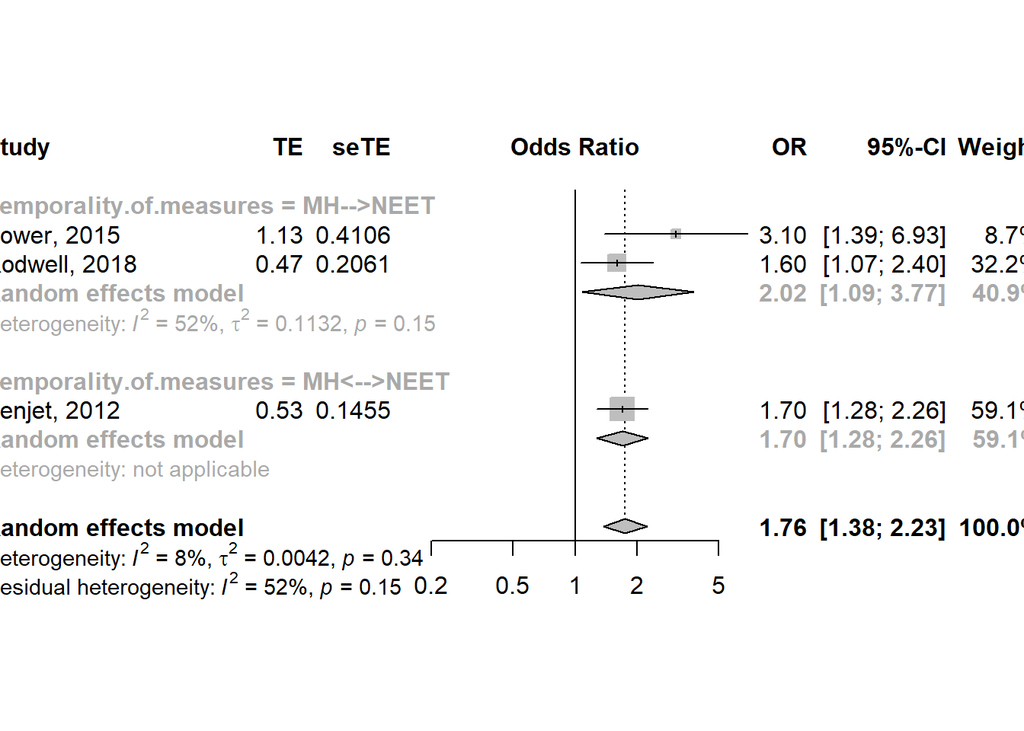

```r
forest(meta.MHany.Gall.rep0.dir)
```

### ANY - geography

In order to go back to “any lifetime disorder” for subgroup analysis by geography, must regenerate the original subset.

```r
MHany.Gall.rep0 <- neet2[which(neet2$Any==1 & neet2$Gender=="all" & is.na(neet2$Repeated_sample)),]

head(MHany.Gall.rep0)
```

|  | X | Study | Country | study_no | Mental.health.measures | Temporality.of.measures | Results | Repeated_sample | MH_measure | MH.measure.included | Gender | OR | LowerCI | UpperCI | OR_ln | lower_ln | upper_ln | SE | LowerCI_sens | UpperCI_sens | Distress | Mood | Anxiety | Behavioral | Alcohol | Cannabis | Drug | Suicidal | Any |
| --- | --- | --- | --- | --- | --- | --- | --- | --- | --- | --- | --- | --- | --- | --- | --- | --- | --- | --- | --- | --- | --- | --- | --- | --- | --- | --- | --- | --- | --- |
| 1 | 28 | Benjet, 2012 | Mexico | benjet 2012 5 | Any disorder | MHNEET | OR 1.7, 95% CI 1.3, 2.3 | NA | any | NA | all | 1.7 | 1.30 | 2.3 | 0.5306283 | 0.26236426 | 0.8329091 | 0.1455472 | NA | NA | 0 | 0 | 0 | 0 | 0 | 0 | 0 | 0 | 1 |
| 2 | 111 | Power, 2015 | Ireland | power 2015 7 | Any lifetime disorder | MHNEET | OR 2.9, 95% CI 1.1, 7.2 | NA | any | NA | all | 2.9 | 1.10 | 7.2 | 1.0647107 | 0.09531018 | 1.9740810 | 0.4792783 | NA | NA | 0 | 0 | 0 | 0 | 0 | 0 | 0 | 0 | 1 |
| 3 | 115 | Power, 2015 | Ireland | power 2015 10 | Any diagnosis in adolescence | MH-->NEET | OR 3.1, 95% CI 1.4, 7.0 | NA | any | NA | all | 3.1 | 1.40 | 7.0 | 1.1314021 | 0.33647224 | 1.9459101 | 0.4105709 | NA | NA | 0 | 0 | 0 | 0 | 0 | 0 | 0 | 0 | 1 |
| 4 | 117 | Rodwell, 2018 | Australia | rodwell 2018 1 | Common mental disorders | MH-->NEET | OR 1.60, 95% CI 1.07, 2.40 | NA | any | NA | all | 1.6 | 1.07 | 2.4 | 0.4700036 | 0.06765865 | 0.8754687 | 0.2060740 | NA | NA | 0 | 0 | 0 | 0 | 0 | 0 | 0 | 0 | 1 |

going back to “any lifetime disorder” only

```r
MHany.Gall.rep0 <- MHany.Gall.rep0[c(1,2,4),]

head(MHany.Gall.rep0)
```

|  | X | Study | Country | study_no | Mental.health.measures | Temporality.of.measures | Results | Repeated_sample | MH_measure | MH.measure.included | Gender | OR | LowerCI | UpperCI | OR_ln | lower_ln | upper_ln | SE | LowerCI_sens | UpperCI_sens | Distress | Mood | Anxiety | Behavioral | Alcohol | Cannabis | Drug | Suicidal | Any |
| --- | --- | --- | --- | --- | --- | --- | --- | --- | --- | --- | --- | --- | --- | --- | --- | --- | --- | --- | --- | --- | --- | --- | --- | --- | --- | --- | --- | --- | --- |
| 1 | 28 | Benjet, 2012 | Mexico | benjet 2012 5 | Any disorder | MHNEET | OR 1.7, 95% CI 1.3, 2.3 | NA | any | NA | all | 1.7 | 1.30 | 2.3 | 0.5306283 | 0.26236426 | 0.8329091 | 0.1455472 | NA | NA | 0 | 0 | 0 | 0 | 0 | 0 | 0 | 0 | 1 |
| 2 | 111 | Power, 2015 | Ireland | power 2015 7 | Any lifetime disorder | MHNEET | OR 2.9, 95% CI 1.1, 7.2 | NA | any | NA | all | 2.9 | 1.10 | 7.2 | 1.0647107 | 0.09531018 | 1.9740810 | 0.4792783 | NA | NA | 0 | 0 | 0 | 0 | 0 | 0 | 0 | 0 | 1 |
| 4 | 117 | Rodwell, 2018 | Australia | rodwell 2018 1 | Common mental disorders | MH-->NEET | OR 1.60, 95% CI 1.07, 2.40 | NA | any | NA | all | 1.6 | 1.07 | 2.4 | 0.4700036 | 0.06765865 | 0.8754687 | 0.2060740 | NA | NA | 0 | 0 | 0 | 0 | 0 | 0 | 0 | 0 | 1 |

```r
meta.MHany.Gall.rep0 <- metagen(OR_ln,
                                SE,
                                data=MHany.Gall.rep0,
                                studlab=paste(Study),
                                comb.fixed = FALSE,
                                comb.random = TRUE,
                                method.tau = "DL",
                                hakn = FALSE,
                                prediction=FALSE,
                                sm="OR")
meta.MHany.Gall.rep0
```

```
##                   OR           95%-CI %W(random)
## Benjet, 2012  1.7000 [1.2781; 2.2612]       62.9
## Power, 2015   2.9000 [1.1335; 7.4193]        5.8
## Rodwell, 2018 1.6000 [1.0683; 2.3962]       31.4
##
## Number of studies combined: k = 3
##
##                          OR           95%-CI    z  p-value
## Random effects model 1.7204 [1.3722; 2.1570] 4.70 < 0.0001
##
## Quantifying heterogeneity:
## tau^2 = 0; H = 1.00 [1.00; 2.52]; I^2 = 0.0% [0.0%; 84.2%]
##
## Test of heterogeneity:
##     Q d.f. p-value
##  1.32    2  0.5175
##
## Details on meta-analytical method:
## - Inverse variance method
## - DerSimonian-Laird estimator for tau^2
```

```r
meta.MHany.Gall.rep0.geo<-update.meta(meta.MHany.Gall.rep0,
                                      byvar=Country,
                                      comb.random = TRUE,
                                      comb.fixed = FALSE)
meta.MHany.Gall.rep0.geo
```

```
##                   OR           95%-CI %W(random) Country
## Benjet, 2012  1.7000 [1.2781; 2.2612]       62.9       5
## Power, 2015   2.9000 [1.1335; 7.4193]        5.8       4
## Rodwell, 2018 1.6000 [1.0683; 2.3962]       31.4       1
##
## Number of studies combined: k = 3
##
##                          OR           95%-CI    z  p-value
## Random effects model 1.7204 [1.3722; 2.1570] 4.70 < 0.0001
##
## Quantifying heterogeneity:
## tau^2 = 0; H = 1.00 [1.00; 2.52]; I^2 = 0.0% [0.0%; 84.2%]
##
## Test of heterogeneity:
##     Q d.f. p-value
##  1.32    2  0.5175
##
## Results for subgroups (random effects model):
##                       k     OR           95%-CI    Q tau^2 I^2
## Country = Australia   1 1.6000 [1.0683; 2.3962] 0.00    --  --
## Country = Ireland     1 2.9000 [1.1335; 7.4193] 0.00    --  --
## Country = Mexico      1 1.7000 [1.2781; 2.2612] 0.00    --  --
##
## Test for subgroup differences (random effects model):
##                     Q d.f. p-value
## Between groups   1.32    2  0.5175
##
## Details on meta-analytical method:
## - Inverse variance method
## - DerSimonian-Laird estimator for tau^2
```

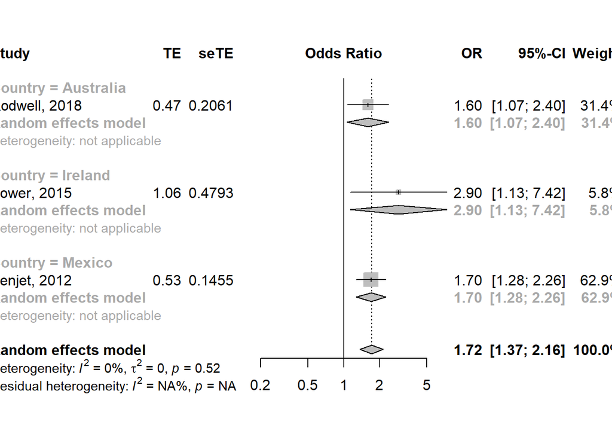

```r
forest(meta.MHany.Gall.rep0.geo)
```

### ANY - gender

```r
MHany.Gbg.rep0 <- neet2[which(neet2$Any==1 & neet2$Gender!="all" & is.na(neet2$Repeated_sample)),]

head(MHany.Gbg.rep0)
```

| X | Study | Country | study_no | Mental.health.measures | Temporality.of.measures | Results | Repeated_sample | MH_measure | MH.measure.included | Gender | OR | LowerCI | UpperCI | OR_ln | lower_ln | upper_ln | SE | LowerCI_sens | UpperCI_sens | Distress | Mood | Anxiety | Behavioral | Alcohol | Cannabis | Drug | Suicidal | Any |
| --- | --- | --- | --- | --- | --- | --- | --- | --- | --- | --- | --- | --- | --- | --- | --- | --- | --- | --- | --- | --- | --- | --- | --- | --- | --- | --- | --- | --- |